# Roof study-v17.1

```python
import numpy as np
import pandas as pd
import seaborn as sns
import matplotlib.pyplot as plt
from IPython.display import Image
from pathlib import Path
```

```python
# to display the all entire tables :
pd.set_option('display.max_rows', None)
pd.set_option('display.max_columns', None)

# or locally
# with pd.option_context('display.max_rows', None, 'display.max_columns', None):
#     display(df)

pd.options.display.float_format = '${:,.2f}'.format
```

## Charge BDD Danube

```python
# replace the variable "this_folder" below by the output of pwd cell
```

```python
pwd
```

```
'U:\\WORK\\code_gpd\\data_analysis\\notebooks_danube\\dispositifs_study\\roof_study'
```

```python
this_folder = Path(r'U:\\WORK\\code_gpd\\data_analysis\\notebooks_danube\\dispositifs_study\\roof_study')
```

```python
danube_csv_file_loc = r"U:\WORK\Danube\BDD\Present version\BddMAPUCE_MAP_V17.1beta_20221118-export.csv"
```

```python
df = pd.read_csv(danube_csv_file_loc, sep=",", index_col="NUMERO_TYPOLOGIE")
```

```python
col_ord = ['USAGE', 'NOM_TYPOLOGIE', 'PERIODE', 'TERRITOIRE',
           'DISPOSITIF_M1',
           'PORTEUR_M1', 'EP_PORTEUR_M1', 'ISOLANT_M1','EP_ISOLANT_M1',
           'REVETEMENT_INT_M1', 'EP_RI_M1', 'REVETEMENT_EXT_M1', 'EP_RE_M1',
           'DISPOSITIF_M2', 'PORTEUR_M2', 'EP_PORTEUR_M2',
           'ISOLANT_M2', 'EP_ISOLANT_M2', 'REVETEMENT_INT_M2', 'EP_RI_M2',
           'REVETEMENT_EXT_M2', 'EP_RE_M2', 'DISPOSITIF_M3', 'PORTEUR_M3',
           'EP_PORTEUR_M3', 'ISOLANT_M3', 'EP_ISOLANT_M3', 'REVETEMENT_INT_M3',
           'EP_RI_M3', 'REVETEMENT_EXT_M3', 'EP_RE_M3',
           'DISPOSITIF_T2', 'PORTEUR_T2', 'EP_PORTEUR_T2', 'ISOLANT_T2',
           'EP_ISOLANT_T2', 'REVETEMENT_INT_T2', 'EP_RI_T2', 'REVETEMENT_EXT_T2', 'EP_RE_T2',
           'TERRITOIRE_SHORT_ID', 'TERRITOIRE_DESC',
           'NUMERO_PERIODE', 'DATES', 'DATE_DEBUT', 'DATE_FIN',
           'POURCENTAGE_VITRAGE', 'TYPE_VITRAGE', 'PROTECTIONS_SOLAIRES',
           'VENTILATION','PERMEABILITE',
           'COUVERTURE_ROUTE','COMPACITE',
           'ID_PLANCHER', 'PLANCHER_RDC','EP_PLANCHER_RDC',
           'PLANCHER_INTERMEDIAIRE', 'EP_PLANCHER_INTER','PLANCHER',
           'DISPOSITIF_T1',
           'PORTEUR_T1', 'EP_PORTEUR_T1', 'ISOLANT_T1', 'EP_ISOLANT_T1',
           'REVETEMENT_INT_T1', 'EP_RI_T1', 'REVETEMENT_EXT_T1', 'EP_RE_T1',
    ]
# order by inputs in the first  columns and then the other columns
df = df[col_ord].sort_values(['PERIODE', 'NOM_TYPOLOGIE',"USAGE","TERRITOIRE"])
df.head()
```

| NUMERO_TYPOLOGIE | USAGE | NOM_TYPOLOGIE | PERIODE | TERRITOIRE | DISPOSITIF_M1 | PORTEUR_M1 | EP_PORTEUR_M1 | ISOLANT_M1 | EP_ISOLANT_M1 | REVETEMENT_INT_M1 | ... | PLANCHER | DISPOSITIF_T1 | PORTEUR_T1 | EP_PORTEUR_T1 | ISOLANT_T1 | EP_ISOLANT_T1 | REVETEMENT_INT_T1 | EP_RI_T1 | REVETEMENT_EXT_T1 | EP_RE_T1 |
| --- | --- | --- | --- | --- | --- | --- | --- | --- | --- | --- | --- | --- | --- | --- | --- | --- | --- | --- | --- | --- | --- |
| AGR_BA_P1_TBR_TF | BATIMENT AGRICOLE | BA | P1 | FRANCE | PAV_M_P1_TBr_br | BRIQUE PLEINE | 60 | NON | 0 | ENDUIT | ... | TERRE BATTUE1NON0 | HAB_T_P1_TBR_TU | STRUCTURE BOIS | 0 | NON | 0 | NON | 0.0 | TUILE | 2.0 |
| AGR_BA_P1_TBO_ARD | BATIMENT AGRICOLE | BA | P1 | FRANCE_BOIS_ARDOISE | PAV_M_P1_TBo-bo | BOIS | 50 | IR | 0 | NON | ... | TERRE BATTUE1NON0 | HAB_T_P1_TPI_AR | STRUCTURE BOIS | 0 | NON | 0 | NON | 0.0 | ARDOISE | 2.0 |
| AGR_BA_P1_TBO_TUI | BATIMENT AGRICOLE | BA | P1 | FRANCE_BOIS_TUILE | PAV_M_P1_TBo-bo | BOIS | 50 | IR | 0 | NON | ... | TERRE BATTUE1NON0 | HAB_T_P1_TBR_TM | STRUCTURE BOIS | 0 | NON | 0 | NON | 0.0 | TUILE MECANIQUE | 2.0 |
| AGR_BA_P1_TBR_TUI | BATIMENT AGRICOLE | BA | P1 | FRANCE_BRIQUE_TUILE | PAV_M_P1_TBr_br | BRIQUE PLEINE | 60 | NON | 0 | ENDUIT | ... | TERRE BATTUE1NON0 | HAB_T_P1_TBR_TU | STRUCTURE BOIS | 0 | NON | 0 | NON | 0.0 | TUILE | 2.0 |
| AGR_BA_P1_TCAL_ARD | BATIMENT AGRICOLE | BA | P1 | FRANCE_PIERRE_CALCAIRE_ARDOISE | PAV_M_P1_TPi_Cal | CALCAIRE | 80 | NON | 0 | NON | ... | TERRE BATTUE1NON0 | HAB_T_P1_TPI_AR | STRUCTURE BOIS | 0 | NON | 0 | NON | 0.0 | ARDOISE | 2.0 |

5 rows × 68 columns

## Study of roof pairs characteristics

```python
len(df["DISPOSITIF_T1"].unique())
```

```
38
```

```python
len(df["DISPOSITIF_M1"].unique())
```

```
66
```

```python
len(df["PLANCHER"].unique())
```

```
11
```

```python
df["arch"] = (df['PERIODE'] + "-" +
              df['NOM_TYPOLOGIE'] + "-" +
              df['USAGE'] + "-" +
              df['TERRITOIRE'])
archs = df["arch"].unique()
```

```python
# exclude cases with territoire France global
archs_nofr = [arch for arch in archs
              if arch.split("-")[-1] != "FRANCE"]
len(archs_nofr)
```

```
128
```

```python
# Take out the ceiling from the archetypes

start = ["-".join(arch.split("-")[:-1])
         for arch in archs_nofr
         ]
print(start[0])

ter_mur = ["_".join(arch.split("-")[-1].split("_")[:-1])
            for arch in archs_nofr
          ]
print(ter_mur[0])

n = range(len(start))
arch_ter_murs = ['-'.join([start[i], ter_mur[i]]) for i in n]
arch_ter_murs[0]
```

```
P1-BA-BATIMENT AGRICOLE
FRANCE_BOIS
```

```
'P1-BA-BATIMENT AGRICOLE-FRANCE_BOIS'
```

```python
# Take the set of the list

print(len(arch_ter_murs))
arch_ter_murs = set(arch_ter_murs)
print(len(arch_ter_murs))
```

```
128
81
```

```python
# Group archetypes in pairs or group of three

two_ceilings = []
three_ceilings =[]
for arch_mur in arch_ter_murs:
    same_mur = []
    for arch in archs_nofr:
#         if arch.split("-")[-1] != "FRANCE":
        if arch_mur in arch:
            same_mur.append(arch)
    if len(same_mur) == 2:
        two_ceilings.append(same_mur)
    elif len(same_mur) > 2:
        three_ceilings.append(same_mur)

print("len two_ceilings is ", len(two_ceilings))
print("len three_ceilings is ", len(three_ceilings))

print("\nthree_ceilings:\n",three_ceilings)
print("\ntwo_ceilings\n",two_ceilings)
```

```
len two_ceilings is  40
len three_ceilings is  4

three_ceilings:
 [['P1-I-HABITAT-FRANCE_PIERRE_CALCAIRE_ARDOISE', 'P1-I-HABITAT-FRANCE_PIERRE_CALCAIRE_TUILE', 'P1-I-HABITAT-FRANCE_PIERRE_CALCAIRE_ZINC'], ['P1-I-CHATEAU-FRANCE_PIERRE_CALCAIRE_ARDOISE', 'P1-I-CHATEAU-FRANCE_PIERRE_CALCAIRE_TUILE', 'P1-I-CHATEAU-FRANCE_PIERRE_CALCAIRE_ZINC'], ['P1-BA-BATIMENT AGRIC…

two_ceilings
 [['P3-I-BATIMENT DE SANTE-FRANCE_ARDOISE', 'P3-I-BATIMENT DE SANTE-FRANCE_TUILE'], ['P1-I-HABITAT-FRANCE_PIERRE_GRES_ARDOISE', 'P1-I-HABITAT-FRANCE_PIERRE_GRES_TUILE'], ['P1-I-TERTIAIRE-FRANCE_BOIS_ARDOISE', 'P1-I-TERTIAIRE-FRANCE_BOIS_TUILE'], ['P1-I-CHATEAU-FRANCE_PIERRE_GRANITE_ARDOISE', 'P1-I-C…
```

```python
# print cases in which the roofs have different properties (besides material)
for pair in two_ceilings:
    print('\n', "-"*100)
    for e in pair:
        print(e)

    df0 = df[df["arch"]==pair[0]]
    df1 = df[df["arch"]==pair[1]]
    pair_df = pd.concat([df0,df1])[["TERRITOIRE",
                                    "REVETEMENT_EXT_T1",
                                    "EP_RE_T1",
                                    "PORTEUR_T1",
                                    "EP_PORTEUR_T1",
                                    "ISOLANT_T1",
                                    "EP_ISOLANT_T1",
                                    "REVETEMENT_INT_T1",
                                    "EP_RI_T1",
                                    ]]
    if sum(pair_df.iloc[1][2:] != pair_df.iloc[0][2:]) != 0:
        display(pair_df)
```

```
 ----------------------------------------------------------------------------------------------------
P6-P-HABITAT-FRANCE_ARDOISE
P6-P-HABITAT-FRANCE_BRIQUE_TUILE

 ----------------------------------------------------------------------------------------------------
P5-P-HABITAT-FRANCE_ARDOISE
P5-P-HABITAT-FRANCE_BRIQUE_TUILE

 ----------------------------------------------------------------------------------------------------
P2-I-HABITAT-FRANCE_ARDOISE
P2-I-HABITAT-FRANCE_TUILE

 ----------------------------------------------------------------------------------------------------
P7-P-HABITAT-FRANCE_ARDOISE
P7-P-HABITAT-FRANCE_BRIQUE_TUILE

 ----------------------------------------------------------------------------------------------------
P1-BA-BATIMENT AGRICOLE-FRANCE_PIERRE_CALCAIRE_ARDOISE
P1-BA-BATIMENT AGRICOLE-FRANCE_PIERRE_CALCAIRE_TUILE

 ----------------------------------------------------------------------------------------------------
P1-I-CHATEAU-FRANCE_PIERRE_GRANITE_ARDOISE
P1-I-CHATEAU-FRANCE_PIERRE_GRANITE_TUILE

 ----------------------------------------------------------------------------------------------------
P7-I-BATIMENT D ENSEIGNEMENT-FRANCE_ARDOISE
P7-I-BATIMENT D ENSEIGNEMENT-FRANCE_TUILE

 ----------------------------------------------------------------------------------------------------
P7-I-BATIMENT DE SANTE-FRANCE_ARDOISE
P7-I-BATIMENT DE SANTE-FRANCE_TUILE

 ----------------------------------------------------------------------------------------------------
P1-P-HABITAT-FRANCE_BOIS_ARDOISE
P1-P-HABITAT-FRANCE_BOIS_TUILE

 ----------------------------------------------------------------------------------------------------
P1-I-HABITAT-FRANCE_BOIS_ARDOISE
P1-I-HABITAT-FRANCE_BOIS_TUILE

```

[output cut: 88 more lines]

```
 ----------------------------------------------------------------------------------------------------
P3-I-HABITAT-FRANCE_ARDOISE
P3-I-HABITAT-FRANCE_TUILE

 ----------------------------------------------------------------------------------------------------
P6-I-HABITAT-FRANCE_ARDOISE
P6-I-HABITAT-FRANCE_TUILE

 ----------------------------------------------------------------------------------------------------
P1-BA-BATIMENT AGRICOLE-FRANCE_BOIS_ARDOISE
P1-BA-BATIMENT AGRICOLE-FRANCE_BOIS_TUILE

 ----------------------------------------------------------------------------------------------------
P1-P-HABITAT-FRANCE_PIERRE_CALCAIRE_TUILE
P1-P-HABITAT-FRANCE_PIERRE_CALCAIRE_ZINC
```

| NUMERO_TYPOLOGIE | TERRITOIRE | REVETEMENT_EXT_T1 | EP_RE_T1 | PORTEUR_T1 | EP_PORTEUR_T1 | ISOLANT_T1 | EP_ISOLANT_T1 | REVETEMENT_INT_T1 | EP_RI_T1 |
| --- | --- | --- | --- | --- | --- | --- | --- | --- | --- |
| HAB_P_P1_TCAL_TUI | FRANCE_PIERRE_CALCAIRE_TUILE | TUILE CANAL | $2.00 | STRUCTURE BOIS | 0 | NON | 0 | NON | $0.00 |
| HAB_P_P1_TCA_ZIN | FRANCE_PIERRE_CALCAIRE_ZINC | COUVERTURE ZINC | $1.00 | STRUCTURE BOIS | 0 | NON | 0 | NON | $0.00 |

```
 ----------------------------------------------------------------------------------------------------
P1-I-TERTIAIRE-FRANCE_PIERRE_GRANITE_ARDOISE
P1-I-TERTIAIRE-FRANCE_PIERRE_GRANITE_TUILE

 ----------------------------------------------------------------------------------------------------
P2-I-BATIMENT D ENSEIGNEMENT-FRANCE_ARDOISE
P2-I-BATIMENT D ENSEIGNEMENT-FRANCE_TUILE

 ----------------------------------------------------------------------------------------------------
P2-I-BATIMENT DE SANTE-FRANCE_ARDOISE
P2-I-BATIMENT DE SANTE-FRANCE_TUILE

 ----------------------------------------------------------------------------------------------------
P1-I-HABITAT-FRANCE_PIERRE_GRANITE_ARDOISE
P1-I-HABITAT-FRANCE_PIERRE_GRANITE_TUILE
```

```python
for group in three_ceilings:
    print('\n', "-"*100)
    for e in group:
        print(e)

    df0 = df[df["arch"]==group[0]]
    df1 = df[df["arch"]==group[1]]
    df2 = df[df["arch"]==group[2]]

    group_df = pd.concat([df0,df1,df2])[["TERRITOIRE",
                                    "REVETEMENT_EXT_T1",
                                    "EP_RE_T1",
                                    "PORTEUR_T1",
                                    "EP_PORTEUR_T1",
                                    "ISOLANT_T1",
                                    "EP_ISOLANT_T1",
                                    "REVETEMENT_INT_T1",
                                    "EP_RI_T1",
                                    ]]
    if (sum(group_df.iloc[0][2:] != group_df.iloc[1][2:]) +
        sum(group_df.iloc[0][2:] != group_df.iloc[2][2:])
        +
        sum(group_df.iloc[1][2:] != group_df.iloc[2][2:])
           )!= 0:
        display(group_df)
```

```
 ----------------------------------------------------------------------------------------------------
P1-I-CHATEAU-FRANCE_PIERRE_CALCAIRE_ARDOISE
P1-I-CHATEAU-FRANCE_PIERRE_CALCAIRE_TUILE
P1-I-CHATEAU-FRANCE_PIERRE_CALCAIRE_ZINC
```

| NUMERO_TYPOLOGIE | TERRITOIRE | REVETEMENT_EXT_T1 | EP_RE_T1 | PORTEUR_T1 | EP_PORTEUR_T1 | ISOLANT_T1 | EP_ISOLANT_T1 | REVETEMENT_INT_T1 | EP_RI_T1 |
| --- | --- | --- | --- | --- | --- | --- | --- | --- | --- |
| CHA_I_P1_TCAL_ARD | FRANCE_PIERRE_CALCAIRE_ARDOISE | ARDOISE | $2.00 | STRUCTURE BOIS | 0 | NON | 0 | NON | $0.00 |
| CHA_I_P1_TCAL_TUI | FRANCE_PIERRE_CALCAIRE_TUILE | TUILE | $2.00 | STRUCTURE BOIS | 0 | NON | 0 | NON | $0.00 |
| CHA_I_P1_TCAL_ZIN | FRANCE_PIERRE_CALCAIRE_ZINC | COUVERTURE ZINC | $1.00 | STRUCTURE BOIS | 0 | NON | 0 | NON | $0.00 |

```
 ----------------------------------------------------------------------------------------------------
P1-I-TERTIAIRE-FRANCE_PIERRE_CALCAIRE_ARDOISE
P1-I-TERTIAIRE-FRANCE_PIERRE_CALCAIRE_TUILE
P1-I-TERTIAIRE-FRANCE_PIERRE_CALCAIRE_ZINC
```

| NUMERO_TYPOLOGIE | TERRITOIRE | REVETEMENT_EXT_T1 | EP_RE_T1 | PORTEUR_T1 | EP_PORTEUR_T1 | ISOLANT_T1 | EP_ISOLANT_T1 | REVETEMENT_INT_T1 | EP_RI_T1 |
| --- | --- | --- | --- | --- | --- | --- | --- | --- | --- |
| TER_I_P1_TCAL_ARD | FRANCE_PIERRE_CALCAIRE_ARDOISE | ARDOISE | $2.00 | STRUCTURE BOIS | 0 | NON | 0 | NON | $0.00 |
| TER_I_P1_TCAL_TUI | FRANCE_PIERRE_CALCAIRE_TUILE | TUILE PLATE | $2.00 | STRUCTURE BOIS | 0 | NON | 0 | NON | $0.00 |
| TER_I_P1_TCA_ZIN | FRANCE_PIERRE_CALCAIRE_ZINC | COUVERTURE ZINC | $1.00 | STRUCTURE BOIS | 0 | NON | 0 | NON | $0.00 |

```
 ----------------------------------------------------------------------------------------------------
P1-I-HABITAT-FRANCE_PIERRE_CALCAIRE_ARDOISE
P1-I-HABITAT-FRANCE_PIERRE_CALCAIRE_TUILE
P1-I-HABITAT-FRANCE_PIERRE_CALCAIRE_ZINC
```

| NUMERO_TYPOLOGIE | TERRITOIRE | REVETEMENT_EXT_T1 | EP_RE_T1 | PORTEUR_T1 | EP_PORTEUR_T1 | ISOLANT_T1 | EP_ISOLANT_T1 | REVETEMENT_INT_T1 | EP_RI_T1 |
| --- | --- | --- | --- | --- | --- | --- | --- | --- | --- |
| HAB_I_P1_TCAL_ARD | FRANCE_PIERRE_CALCAIRE_ARDOISE | ARDOISE | $2.00 | STRUCTURE BOIS | 0 | NON | 0 | NON | $0.00 |
| HAB_I_P1_TCAL_TUI | FRANCE_PIERRE_CALCAIRE_TUILE | TUILE PLATE | $2.00 | STRUCTURE BOIS | 0 | NON | 0 | NON | $0.00 |
| HAB_I_P1_TCA_ZIN | FRANCE_PIERRE_CALCAIRE_ZINC | COUVERTURE ZINC | $1.00 | STRUCTURE BOIS | 0 | NON | 0 | NON | $0.00 |

### Conclusion

L'unique difference entre les caractéristiques des toits (à part révétement extérieur), est sur l'epaisseur du revetement, uniquement pour les cas où il y a de la toiture zinc.

## Dispositifs

### Check the archetypes per roof dispositif

```python
for disp_t in df["DISPOSITIF_T1"].unique():
    print("\n",disp_t)
    display(df[df["DISPOSITIF_T1"]==disp_t][["TERRITOIRE",
                                            "PERIODE",
                                            "PORTEUR_T1",
                                            "EP_PORTEUR_T1",
                                            "ISOLANT_T1",
                                            "EP_ISOLANT_T1",
                                            "REVETEMENT_EXT_T1",
                                            "EP_RE_T1",
                                            "REVETEMENT_INT_T1",
                                            "EP_RI_T1",
                                            ]])
```

```
 HAB_T_P1_TBR_TU
```

| NUMERO_TYPOLOGIE | TERRITOIRE | PERIODE | PORTEUR_T1 | EP_PORTEUR_T1 | ISOLANT_T1 | EP_ISOLANT_T1 | REVETEMENT_EXT_T1 | EP_RE_T1 | REVETEMENT_INT_T1 | EP_RI_T1 |
| --- | --- | --- | --- | --- | --- | --- | --- | --- | --- | --- |
| AGR_BA_P1_TBR_TF | FRANCE | P1 | STRUCTURE BOIS | 0 | NON | 0 | TUILE | 2.0 | NON | 0.0 |
| AGR_BA_P1_TBR_TUI | FRANCE_BRIQUE_TUILE | P1 | STRUCTURE BOIS | 0 | NON | 0 | TUILE | 2.0 | NON | 0.0 |
| IND_BA_P1_TF | FRANCE | P1 | STRUCTURE BOIS | 0 | NON | 0 | TUILE | 2.0 | NON | 0.0 |
| IND_BA_P1_TBR_TUI | FRANCE_BRIQUE_TUILE | P1 | STRUCTURE BOIS | 0 | NON | 0 | TUILE | 2.0 | NON | 0.0 |
| SAN_I_P1_TF | FRANCE | P1 | STRUCTURE BOIS | 0 | NON | 0 | TUILE | 2.0 | NON | 0.0 |
| REL_I_P1_TBR_TUI | FRANCE_BRIQUE_TUILE | P1 | STRUCTURE BOIS | 0 | NON | 0 | TUILE | 2.0 | NON | 0.0 |
| REL_I_P1_TSCH_TUI | FRANCE_PIERRE_SCHISTE_TUILE | P1 | STRUCTURE BOIS | 0 | NON | 0 | TUILE | 2.0 | NON | 0.0 |
| CHA_I_P1_TCAL_TUI | FRANCE_PIERRE_CALCAIRE_TUILE | P1 | STRUCTURE BOIS | 0 | NON | 0 | TUILE | 2.0 | NON | 0.0 |
| COM_I_P1_TF | FRANCE | P1 | STRUCTURE BOIS | 0 | NON | 0 | TUILE | 2.0 | NON | 0.0 |
| HAB_I_P1_TF | FRANCE | P1 | STRUCTURE BOIS | 0 | NON | 0 | TUILE | 2.0 | NON | 0.0 |
| TER_I_P1_TF | FRANCE | P1 | STRUCTURE BOIS | 0 | NON | 0 | TUILE | 2.0 | NON | 0.0 |
| HAB_P_P1_TGRE_TUI | FRANCE_PIERRE_GRES_TUILE | P1 | STRUCTURE BOIS | 0 | NON | 0 | TUILE | 2.0 | NON | 0.0 |
| LNC_P_P1_TF | FRANCE | P1 | STRUCTURE BOIS | 0 | NON | 0 | TUILE | 2.0 | NON | 0.0 |
| LNC_P_P2_TF | FRANCE | P2 | STRUCTURE BOIS | 0 | NON | 0 | TUILE | 2.0 | NON | 0.0 |
| LNC_P_P3_TF | FRANCE | P3 | STRUCTURE BOIS | 0 | NON | 0 | TUILE | 2.0 | NON | 0.0 |
| LNC_P_P4_TF | FRANCE | P4 | STRUCTURE BOIS | 0 | NON | 0 | TUILE | 2.0 | NON | 0.0 |
| LNC_P_P5_TF | FRANCE | P5 | STRUCTURE BOIS | 0 | NON | 0 | TUILE | 2.0 | NON | 0.0 |
| LNC_P_P6_TF | FRANCE | P6 | STRUCTURE BOIS | 0 | NON | 0 | TUILE | 2.0 | NON | 0.0 |
| LNC_P_P7_TF | FRANCE | P7 | STRUCTURE BOIS | 0 | NON | 0 | TUILE | 2.0 | NON | 0.0 |

```
 HAB_T_P1_TPI_AR
```

| NUMERO_TYPOLOGIE | TERRITOIRE | PERIODE | PORTEUR_T1 | EP_PORTEUR_T1 | ISOLANT_T1 | EP_ISOLANT_T1 | REVETEMENT_EXT_T1 | EP_RE_T1 | REVETEMENT_INT_T1 | EP_RI_T1 |
| --- | --- | --- | --- | --- | --- | --- | --- | --- | --- | --- |
| AGR_BA_P1_TBO_ARD | FRANCE_BOIS_ARDOISE | P1 | STRUCTURE BOIS | 0 | NON | 0 | ARDOISE | 2.0 | NON | 0.0 |
| AGR_BA_P1_TCAL_ARD | FRANCE_PIERRE_CALCAIRE_ARDOISE | P1 | STRUCTURE BOIS | 0 | NON | 0 | ARDOISE | 2.0 | NON | 0.0 |
| AGR_BA_P1_TGRA_ARD | FRANCE_PIERRE_GRANITE_ARDOISE | P1 | STRUCTURE BOIS | 0 | NON | 0 | ARDOISE | 2.0 | NON | 0.0 |
| AGR_BA_P1_TGRE_ARD | FRANCE_PIERRE_GRES_ARDOISE | P1 | STRUCTURE BOIS | 0 | NON | 0 | ARDOISE | 2.0 | NON | 0.0 |
| AGR_BA_P1_TVOL_ARD | FRANCE_PIERRE_VOLCANIQUE_ARDOISE | P1 | STRUCTURE BOIS | 0 | NON | 0 | ARDOISE | 2.0 | NON | 0.0 |
| SCO_I_P1_TF | FRANCE | P1 | STRUCTURE BOIS | 0 | NON | 0 | ARDOISE | 2.0 | NON | 0.0 |
| SAN_I_P1_TAR | FRANCE_PIERRE_ARDOISE | P1 | STRUCTURE BOIS | 0 | NON | 0 | ARDOISE | 2.0 | NON | 0.0 |
| REL_I_P1_TVOL_ARD | FRANCE | P1 | STRUCTURE BOIS | 0 | NON | 0 | ARDOISE | 2.0 | NON | 0.0 |
| REL_I_P1_TF | FRANCE_PIERRE_ARDOISE | P1 | STRUCTURE BOIS | 0 | NON | 0 | ARDOISE | 2.0 | NON | 0.0 |
| CHA_I_P1_TF | FRANCE | P1 | STRUCTURE BOIS | 0 | NON | 0 | ARDOISE | 2.0 | NON | 0.0 |
| CHA_I_P1_TCAL_ARD | FRANCE_PIERRE_CALCAIRE_ARDOISE | P1 | STRUCTURE BOIS | 0 | NON | 0 | ARDOISE | 2.0 | NON | 0.0 |
| CHA_I_P1_TGRA_ARD | FRANCE_PIERRE_GRANITE_ARDOISE | P1 | STRUCTURE BOIS | 0 | NON | 0 | ARDOISE | 2.0 | NON | 0.0 |
| CHA_I_P1_TGRE_ARD | FRANCE_PIERRE_GRES_ARDOISE | P1 | STRUCTURE BOIS | 0 | NON | 0 | ARDOISE | 2.0 | NON | 0.0 |
| CHA_I_P1_TVOL_ARD | FRANCE_PIERRE_VOLCANIQUE_ARDOISE | P1 | STRUCTURE BOIS | 0 | NON | 0 | ARDOISE | 2.0 | NON | 0.0 |
| HAB_I_P1_TBO_ARD | FRANCE_BOIS_ARDOISE | P1 | STRUCTURE BOIS | 0 | NON | 0 | ARDOISE | 2.0 | NON | 0.0 |
| HAB_I_P1_TCAL_ARD | FRANCE_PIERRE_CALCAIRE_ARDOISE | P1 | STRUCTURE BOIS | 0 | NON | 0 | ARDOISE | 2.0 | NON | 0.0 |
| HAB_I_P1_TGRA_ARD | FRANCE_PIERRE_GRANITE_ARDOISE | P1 | STRUCTURE BOIS | 0 | NON | 0 | ARDOISE | 2.0 | NON | 0.0 |
| HAB_I_P1_TGRE_ARD | FRANCE_PIERRE_GRES_ARDOISE | P1 | STRUCTURE BOIS | 0 | NON | 0 | ARDOISE | 2.0 | NON | 0.0 |
| HAB_I_P1_TVOL_ARD | FRANCE_PIERRE_VOLCANIQUE_ARDOISE | P1 | STRUCTURE BOIS | 0 | NON | 0 | ARDOISE | 2.0 | NON | 0.0 |
| TER_I_P1_TBO_ARD | FRANCE_BOIS_ARDOISE | P1 | STRUCTURE BOIS | 0 | NON | 0 | ARDOISE | 2.0 | NON | 0.0 |
| TER_I_P1_TCAL_ARD | FRANCE_PIERRE_CALCAIRE_ARDOISE | P1 | STRUCTURE BOIS | 0 | NON | 0 | ARDOISE | 2.0 | NON | 0.0 |
| TER_I_P1_TGRA_ARD | FRANCE_PIERRE_GRANITE_ARDOISE | P1 | STRUCTURE BOIS | 0 | NON | 0 | ARDOISE | 2.0 | NON | 0.0 |
| TER_I_P1_TGRE_ARD | FRANCE_PIERRE_GRES_ARDOISE | P1 | STRUCTURE BOIS | 0 | NON | 0 | ARDOISE | 2.0 | NON | 0.0 |
| TER_I_P1_TVOL_ARD | FRANCE_PIERRE_VOLCANIQUE_ARDOISE | P1 | STRUCTURE BOIS | 0 | NON | 0 | ARDOISE | 2.0 | NON | 0.0 |
| HAB_P_P1_TCAL_ARD | FRANCE | P1 | STRUCTURE BOIS | 0 | NON | 0 | ARDOISE | 2.0 | NON | 0.0 |
| HAB_P_P1_TBO_ARD | FRANCE_BOIS_ARDOISE | P1 | STRUCTURE BOIS | 0 | NON | 0 | ARDOISE | 2.0 | NON | 0.0 |
| HAB_P_P1_TGRA_ARD | FRANCE_PIERRE_GRANITE_ARDOISE | P1 | STRUCTURE BOIS | 0 | NON | 0 | ARDOISE | 2.0 | NON | 0.0 |
| HAB_P_P1_TGRE_ARD | FRANCE_PIERRE_GRES_ARDOISE | P1 | STRUCTURE BOIS | 0 | NON | 0 | ARDOISE | 2.0 | NON | 0.0 |
| HAB_P_P1_TVOL_ARD | FRANCE_PIERRE_VOLCANIQUE_ARDOISE | P1 | STRUCTURE BOIS | 0 | NON | 0 | ARDOISE | 2.0 | NON | 0.0 |

```
 HAB_T_P1_TBR_TM
```

| NUMERO_TYPOLOGIE | TERRITOIRE | PERIODE | PORTEUR_T1 | EP_PORTEUR_T1 | ISOLANT_T1 | EP_ISOLANT_T1 | REVETEMENT_EXT_T1 | EP_RE_T1 | REVETEMENT_INT_T1 | EP_RI_T1 |
| --- | --- | --- | --- | --- | --- | --- | --- | --- | --- | --- |
| AGR_BA_P1_TBO_TUI | FRANCE_BOIS_TUILE | P1 | STRUCTURE BOIS | 0 | NON | 0 | TUILE MECANIQUE | 2.0 | NON | 0.0 |
| HAB_I_P1_TBO_TUI | FRANCE_BOIS_TUILE | P1 | STRUCTURE BOIS | 0 | NON | 0 | TUILE MECANIQUE | 2.0 | NON | 0.0 |
| TER_I_P1_TBO_TUI | FRANCE_BOIS_TUILE | P1 | STRUCTURE BOIS | 0 | NON | 0 | TUILE MECANIQUE | 2.0 | NON | 0.0 |

```
 HAB_T_P1_TBR_TP
```

| NUMERO_TYPOLOGIE | TERRITOIRE | PERIODE | PORTEUR_T1 | EP_PORTEUR_T1 | ISOLANT_T1 | EP_ISOLANT_T1 | REVETEMENT_EXT_T1 | EP_RE_T1 | REVETEMENT_INT_T1 | EP_RI_T1 |
| --- | --- | --- | --- | --- | --- | --- | --- | --- | --- | --- |
| AGR_BA_P1_TCAL_TUI | FRANCE_PIERRE_CALCAIRE_TUILE | P1 | STRUCTURE BOIS | 0 | NON | 0 | TUILE PLATE | 2.0 | NON | 0.0 |
| AGR_BA_P1_TGRA_TUI | FRANCE_PIERRE_GRANITE_TUILE | P1 | STRUCTURE BOIS | 0 | NON | 0 | TUILE PLATE | 2.0 | NON | 0.0 |
| AGR_BA_P1_TGRE_TUI | FRANCE_PIERRE_GRES_TUILE | P1 | STRUCTURE BOIS | 0 | NON | 0 | TUILE PLATE | 2.0 | NON | 0.0 |
| AGR_BA_P1_TMEU | FRANCE_PIERRE_MEULIERE_TUILE | P1 | STRUCTURE BOIS | 0 | NON | 0 | TUILE PLATE | 2.0 | NON | 0.0 |
| AGR_BA_P1_TSCH_TUI | FRANCE_PIERRE_SCHISTE_TUILE | P1 | STRUCTURE BOIS | 0 | NON | 0 | TUILE PLATE | 2.0 | NON | 0.0 |
| AGR_BA_P1_TER_TUI | FRANCE_TERRE_TUILE | P1 | STRUCTURE BOIS | 0 | NON | 0 | TUILE PLATE | 2.0 | NON | 0.0 |
| CHA_I_P1_TGAL_TUI | FRANCE_PIERRE_GALET_TUILE | P1 | STRUCTURE BOIS | 0 | NON | 0 | TUILE PLATE | 2.0 | NON | 0.0 |
| CHA_I_P1_TGRE_TUI | FRANCE_PIERRE_GRES_TUILE | P1 | STRUCTURE BOIS | 0 | NON | 0 | TUILE PLATE | 2.0 | NON | 0.0 |
| CHA_I_P1_TSCH_TUI | FRANCE_PIERRE_SCHISTE_TUILE | P1 | STRUCTURE BOIS | 0 | NON | 0 | TUILE PLATE | 2.0 | NON | 0.0 |
| CHA_I_P1_TER_TUI | FRANCE_TERRE_TUILE | P1 | STRUCTURE BOIS | 0 | NON | 0 | TUILE PLATE | 2.0 | NON | 0.0 |
| HAB_I_P1_TCAL_TUI | FRANCE_PIERRE_CALCAIRE_TUILE | P1 | STRUCTURE BOIS | 0 | NON | 0 | TUILE PLATE | 2.0 | NON | 0.0 |
| HAB_I_P1_TGNE_TUI | FRANCE_PIERRE_GNEISS_TUILE | P1 | STRUCTURE BOIS | 0 | NON | 0 | TUILE PLATE | 2.0 | NON | 0.0 |
| HAB_I_P1_TGRA_TUI | FRANCE_PIERRE_GRANITE_TUILE | P1 | STRUCTURE BOIS | 0 | NON | 0 | TUILE PLATE | 2.0 | NON | 0.0 |
| HAB_I_P1_TGRE_TUI | FRANCE_PIERRE_GRES_TUILE | P1 | STRUCTURE BOIS | 0 | NON | 0 | TUILE PLATE | 2.0 | NON | 0.0 |
| HAB_I_P1_TMEU | FRANCE_PIERRE_MEULIERE_TUILE | P1 | STRUCTURE BOIS | 0 | NON | 0 | TUILE PLATE | 2.0 | NON | 0.0 |
| HAB_I_P1_TSCH_TUI | FRANCE_PIERRE_SCHISTE_TUILE | P1 | STRUCTURE BOIS | 0 | NON | 0 | TUILE PLATE | 2.0 | NON | 0.0 |
| TER_I_P1_TCAL_TUI | FRANCE_PIERRE_CALCAIRE_TUILE | P1 | STRUCTURE BOIS | 0 | NON | 0 | TUILE PLATE | 2.0 | NON | 0.0 |
| TER_I_P1_TGNE_TUI | FRANCE_PIERRE_GNEISS_TUILE | P1 | STRUCTURE BOIS | 0 | NON | 0 | TUILE PLATE | 2.0 | NON | 0.0 |
| TER_I_P1_TGRA_TUI | FRANCE_PIERRE_GRANITE_TUILE | P1 | STRUCTURE BOIS | 0 | NON | 0 | TUILE PLATE | 2.0 | NON | 0.0 |
| TER_I_P1_TGRE_TUI | FRANCE_PIERRE_GRES_TUILE | P1 | STRUCTURE BOIS | 0 | NON | 0 | TUILE PLATE | 2.0 | NON | 0.0 |
| TER_I_P1_TMEU | FRANCE_PIERRE_MEULIERE_TUILE | P1 | STRUCTURE BOIS | 0 | NON | 0 | TUILE PLATE | 2.0 | NON | 0.0 |
| TER_I_P1_TSCH_TUI | FRANCE_PIERRE_SCHISTE_TUILE | P1 | STRUCTURE BOIS | 0 | NON | 0 | TUILE PLATE | 2.0 | NON | 0.0 |
| HAB_P_P1_TBO_TUI | FRANCE_BOIS_TUILE | P1 | STRUCTURE BOIS | 0 | NON | 0 | TUILE PLATE | 2.0 | NON | 0.0 |
| HAB_P_P1_TGNE_TUI | FRANCE_PIERRE_GNEISS_TUILE | P1 | STRUCTURE BOIS | 0 | NON | 0 | TUILE PLATE | 2.0 | NON | 0.0 |
| HAB_P_P1_TGRA_TUI | FRANCE_PIERRE_GRANITE_TUILE | P1 | STRUCTURE BOIS | 0 | NON | 0 | TUILE PLATE | 2.0 | NON | 0.0 |
| HAB_P_P1_TMEU | FRANCE_PIERRE_MEULIERE_TUILE | P1 | STRUCTURE BOIS | 0 | NON | 0 | TUILE PLATE | 2.0 | NON | 0.0 |
| HAB_P_P1_TSCH_TUI | FRANCE_PIERRE_SCHISTE_TUILE | P1 | STRUCTURE BOIS | 0 | NON | 0 | TUILE PLATE | 2.0 | NON | 0.0 |

```
 CHA_T_P1_TZINC
```

| NUMERO_TYPOLOGIE | TERRITOIRE | PERIODE | PORTEUR_T1 | EP_PORTEUR_T1 | ISOLANT_T1 | EP_ISOLANT_T1 | REVETEMENT_EXT_T1 | EP_RE_T1 | REVETEMENT_INT_T1 | EP_RI_T1 |
| --- | --- | --- | --- | --- | --- | --- | --- | --- | --- | --- |
| AGR_BA_P1_TCAL_ZIN | FRANCE_PIERRE_CALCAIRE_ZINC | P1 | STRUCTURE BOIS | 0 | NON | 0 | COUVERTURE ZINC | 1.0 | NON | 0.0 |
| CHA_I_P1_TCAL_ZIN | FRANCE_PIERRE_CALCAIRE_ZINC | P1 | STRUCTURE BOIS | 0 | NON | 0 | COUVERTURE ZINC | 1.0 | NON | 0.0 |
| HAB_I_P1_TCA_ZIN | FRANCE_PIERRE_CALCAIRE_ZINC | P1 | STRUCTURE BOIS | 0 | NON | 0 | COUVERTURE ZINC | 1.0 | NON | 0.0 |
| TER_I_P1_TCA_ZIN | FRANCE_PIERRE_CALCAIRE_ZINC | P1 | STRUCTURE BOIS | 0 | NON | 0 | COUVERTURE ZINC | 1.0 | NON | 0.0 |
| HAB_P_P1_TCA_ZIN | FRANCE_PIERRE_CALCAIRE_ZINC | P1 | STRUCTURE BOIS | 0 | NON | 0 | COUVERTURE ZINC | 1.0 | NON | 0.0 |

```
 HAB_T_P1_TBR_TC
```

| NUMERO_TYPOLOGIE | TERRITOIRE | PERIODE | PORTEUR_T1 | EP_PORTEUR_T1 | ISOLANT_T1 | EP_ISOLANT_T1 | REVETEMENT_EXT_T1 | EP_RE_T1 | REVETEMENT_INT_T1 | EP_RI_T1 |
| --- | --- | --- | --- | --- | --- | --- | --- | --- | --- | --- |
| AGR_BA_P1_TGAL_TUI | FRANCE_PIERRE_GALET_TUILE | P1 | STRUCTURE BOIS | 0 | NON | 0 | TUILE CANAL | 2.0 | NON | 0.0 |
| AGR_BA_P1_TGNE | FRANCE_PIERRE_GNEISS_TUILE | P1 | STRUCTURE BOIS | 0 | NON | 0 | TUILE CANAL | 2.0 | NON | 0.0 |
| CHA_I_P1_TBR_TUI | FRANCE_BRIQUE_TUILE | P1 | STRUCTURE BOIS | 0 | NON | 0 | TUILE CANAL | 2.0 | NON | 0.0 |
| CHA_I_P1_TGRA_TUI | FRANCE_PIERRE_GRANITE_TUILE | P1 | STRUCTURE BOIS | 0 | NON | 0 | TUILE CANAL | 2.0 | NON | 0.0 |
| HAB_I_P1_TBR_TUI | FRANCE_BRIQUE_TUILE | P1 | STRUCTURE BOIS | 0 | NON | 0 | TUILE CANAL | 2.0 | NON | 0.0 |
| HAB_I_P1_TGAL_TUI | FRANCE_PIERRE_GALET_TUILE | P1 | STRUCTURE BOIS | 0 | NON | 0 | TUILE CANAL | 2.0 | NON | 0.0 |
| TER_I_P1_TBR_TUI | FRANCE_BRIQUE_TUILE | P1 | STRUCTURE BOIS | 0 | NON | 0 | TUILE CANAL | 2.0 | NON | 0.0 |
| TER_I_P1_TGAL_TUI | FRANCE_PIERRE_GALET_TUILE | P1 | STRUCTURE BOIS | 0 | NON | 0 | TUILE CANAL | 2.0 | NON | 0.0 |
| HAB_P_P1_TBR_TUI | FRANCE_BRIQUE_TUILE | P1 | STRUCTURE BOIS | 0 | NON | 0 | TUILE CANAL | 2.0 | NON | 0.0 |
| HAB_P_P1_TCAL_TUI | FRANCE_PIERRE_CALCAIRE_TUILE | P1 | STRUCTURE BOIS | 0 | NON | 0 | TUILE CANAL | 2.0 | NON | 0.0 |
| HAB_P_P1_TGAL_TUI | FRANCE_PIERRE_GALET_TUILE | P1 | STRUCTURE BOIS | 0 | NON | 0 | TUILE CANAL | 2.0 | NON | 0.0 |
| HAB_P_P1_TER_TUI | FRANCE_TERRE_TUILE | P1 | STRUCTURE BOIS | 0 | NON | 0 | TUILE CANAL | 2.0 | NON | 0.0 |

```
 SER_T_P1_TN
```

| NUMERO_TYPOLOGIE | TERRITOIRE | PERIODE | PORTEUR_T1 | EP_PORTEUR_T1 | ISOLANT_T1 | EP_ISOLANT_T1 | REVETEMENT_EXT_T1 | EP_RE_T1 | REVETEMENT_INT_T1 | EP_RI_T1 |
| --- | --- | --- | --- | --- | --- | --- | --- | --- | --- | --- |
| SER_BA_P1_TF | FRANCE | P1 | STRUCTURE METAL | 0 | NON | 0 | SIMPLE VITRAGE | 2.0 | NON | 0.0 |

```
 HAB_T_P1_TBR_TR
```

| NUMERO_TYPOLOGIE | TERRITOIRE | PERIODE | PORTEUR_T1 | EP_PORTEUR_T1 | ISOLANT_T1 | EP_ISOLANT_T1 | REVETEMENT_EXT_T1 | EP_RE_T1 | REVETEMENT_INT_T1 | EP_RI_T1 |
| --- | --- | --- | --- | --- | --- | --- | --- | --- | --- | --- |
| HAB_I_P1_TER_TUI | FRANCE_TERRE_TUILE | P1 | STRUCTURE BOIS | 0 | NON | 0 | TUILE ROMAINE | 2.0 | NON | 0.0 |
| TER_I_P1_TER_TUI | FRANCE_TERRE_TUILE | P1 | STRUCTURE BOIS | 0 | NON | 0 | TUILE ROMAINE | 2.0 | NON | 0.0 |

```
 TER_T_P2_TN_BAC
```

| NUMERO_TYPOLOGIE | TERRITOIRE | PERIODE | PORTEUR_T1 | EP_PORTEUR_T1 | ISOLANT_T1 | EP_ISOLANT_T1 | REVETEMENT_EXT_T1 | EP_RE_T1 | REVETEMENT_INT_T1 | EP_RI_T1 |
| --- | --- | --- | --- | --- | --- | --- | --- | --- | --- | --- |
| AGR_BA_P2_TF | FRANCE | P2 | STRUCTURE METAL | 0 | NON | 0 | TOLE | 0.8 | NON | 0.0 |
| IND_BA_P2_TF | FRANCE | P2 | STRUCTURE METAL | 0 | NON | 0 | TOLE | 0.8 | NON | 0.0 |
| SPO_BA_P2_TF | FRANCE | P2 | STRUCTURE METAL | 0 | NON | 0 | TOLE | 0.8 | NON | 0.0 |
| BA_LNC_P7_TF | FRANCE | P7 | STRUCTURE METAL | 0 | NON | 0 | TOLE | 0.8 | NON | 0.0 |

```
 SER_T_P2_TN
```

| NUMERO_TYPOLOGIE | TERRITOIRE | PERIODE | PORTEUR_T1 | EP_PORTEUR_T1 | ISOLANT_T1 | EP_ISOLANT_T1 | REVETEMENT_EXT_T1 | EP_RE_T1 | REVETEMENT_INT_T1 | EP_RI_T1 |
| --- | --- | --- | --- | --- | --- | --- | --- | --- | --- | --- |
| SER_BA_P2_TF | FRANCE | P2 | STRUCTURE METAL | 0 | NON | 0 | SIMPLE VITRAGE | 2.0 | NON | 0.0 |

```
 HAB_T_P2_TBR_TC
```

| NUMERO_TYPOLOGIE | TERRITOIRE | PERIODE | PORTEUR_T1 | EP_PORTEUR_T1 | ISOLANT_T1 | EP_ISOLANT_T1 | REVETEMENT_EXT_T1 | EP_RE_T1 | REVETEMENT_INT_T1 | EP_RI_T1 |
| --- | --- | --- | --- | --- | --- | --- | --- | --- | --- | --- |
| SCO_I_P2_TF | FRANCE | P2 | STRUCTURE BOIS | 0 | NON | 0 | TUILE CANAL | 2.0 | NON | 0.0 |
| SCO_I_P2_TBR | FRANCE_TUILE | P2 | STRUCTURE BOIS | 0 | NON | 0 | TUILE CANAL | 2.0 | NON | 0.0 |
| SAN_I_P2_TF | FRANCE | P2 | STRUCTURE BOIS | 0 | NON | 0 | TUILE CANAL | 2.0 | NON | 0.0 |
| SAN_I_P2_TBR | FRANCE_TUILE | P2 | STRUCTURE BOIS | 0 | NON | 0 | TUILE CANAL | 2.0 | NON | 0.0 |
| HAB_I_P2_TF | FRANCE | P2 | STRUCTURE BOIS | 0 | NON | 0 | TUILE CANAL | 2.0 | NON | 0.0 |
| HAB_I_P2_TBR | FRANCE_TUILE | P2 | STRUCTURE BOIS | 0 | NON | 0 | TUILE CANAL | 2.0 | NON | 0.0 |
| HAB_P_P2_TF | FRANCE | P2 | STRUCTURE BOIS | 0 | NON | 0 | TUILE CANAL | 2.0 | NON | 0.0 |
| HAB_P_P2_TBR | FRANCE_TUILE | P2 | STRUCTURE BOIS | 0 | NON | 0 | TUILE CANAL | 2.0 | NON | 0.0 |

```
 HAB_T_P2_TPI_AR
```

| NUMERO_TYPOLOGIE | TERRITOIRE | PERIODE | PORTEUR_T1 | EP_PORTEUR_T1 | ISOLANT_T1 | EP_ISOLANT_T1 | REVETEMENT_EXT_T1 | EP_RE_T1 | REVETEMENT_INT_T1 | EP_RI_T1 |
| --- | --- | --- | --- | --- | --- | --- | --- | --- | --- | --- |
| SCO_I_P2_TAR | FRANCE_ARDOISE | P2 | STRUCTURE BOIS | 0 | NON | 0 | ARDOISE | 2.0 | NON | 0.0 |
| SAN_I_P2_TAR | FRANCE_ARDOISE | P2 | STRUCTURE BOIS | 0 | NON | 0 | ARDOISE | 2.0 | NON | 0.0 |
| HAB_I_P2_TAR | FRANCE_ARDOISE | P2 | STRUCTURE BOIS | 0 | NON | 0 | ARDOISE | 2.0 | NON | 0.0 |
| HAB_P_P2_TAR | FRANCE_ARDOISE | P2 | STRUCTURE BOIS | 0 | NON | 0 | ARDOISE | 2.0 | NON | 0.0 |

```
 HAB_T_P2_TN_GR
```

| NUMERO_TYPOLOGIE | TERRITOIRE | PERIODE | PORTEUR_T1 | EP_PORTEUR_T1 | ISOLANT_T1 | EP_ISOLANT_T1 | REVETEMENT_EXT_T1 | EP_RE_T1 | REVETEMENT_INT_T1 | EP_RI_T1 |
| --- | --- | --- | --- | --- | --- | --- | --- | --- | --- | --- |
| REL_I_P2_TF | FRANCE | P2 | DALLE BETON | 20 | NON | 0 | GRAVIER | 5.0 | NON | 0.0 |
| COM_I_P2_TF | FRANCE | P2 | DALLE BETON | 20 | NON | 0 | GRAVIER | 5.0 | NON | 0.0 |
| TER_I_P2_TF | FRANCE | P2 | DALLE BETON | 20 | NON | 0 | GRAVIER | 5.0 | NON | 0.0 |
| HAB_IGH_P2_TF | FRANCE | P2 | DALLE BETON | 20 | NON | 0 | GRAVIER | 5.0 | NON | 0.0 |

```
 TER_T_P3_TN_BAC
```

| NUMERO_TYPOLOGIE | TERRITOIRE | PERIODE | PORTEUR_T1 | EP_PORTEUR_T1 | ISOLANT_T1 | EP_ISOLANT_T1 | REVETEMENT_EXT_T1 | EP_RE_T1 | REVETEMENT_INT_T1 | EP_RI_T1 |
| --- | --- | --- | --- | --- | --- | --- | --- | --- | --- | --- |
| AGR_BA_P3_TF | FRANCE | P3 | STRUCTURE METAL | 0 | NON | 0 | TOLE | 0.8 | NON | 0.0 |
| IND_BA_P3_TF | FRANCE | P3 | STRUCTURE METAL | 0 | NON | 0 | TOLE | 0.8 | NON | 0.0 |
| SPO_BA_P3_TF | FRANCE | P3 | STRUCTURE METAL | 0 | NON | 0 | TOLE | 0.8 | NON | 0.0 |

```
 SER_T_P3_TN
```

| NUMERO_TYPOLOGIE | TERRITOIRE | PERIODE | PORTEUR_T1 | EP_PORTEUR_T1 | ISOLANT_T1 | EP_ISOLANT_T1 | REVETEMENT_EXT_T1 | EP_RE_T1 | REVETEMENT_INT_T1 | EP_RI_T1 |
| --- | --- | --- | --- | --- | --- | --- | --- | --- | --- | --- |
| SER_BA_P3_TF | FRANCE | P3 | STRUCTURE METAL | 0 | NON | 0 | SIMPLE VITRAGE | 2.0 | NON | 0.0 |

```
 HAB_T_P3_TN_TU
```

| NUMERO_TYPOLOGIE | TERRITOIRE | PERIODE | PORTEUR_T1 | EP_PORTEUR_T1 | ISOLANT_T1 | EP_ISOLANT_T1 | REVETEMENT_EXT_T1 | EP_RE_T1 | REVETEMENT_INT_T1 | EP_RI_T1 |
| --- | --- | --- | --- | --- | --- | --- | --- | --- | --- | --- |
| SCO_I_P3_TF | FRANCE | P3 | STRUCTURE BOIS | 0 | NON | 0 | TUILE | 2.0 | NON | 0.0 |
| SCO_I_P3_TBR | FRANCE_TUILE | P3 | STRUCTURE BOIS | 0 | NON | 0 | TUILE | 2.0 | NON | 0.0 |
| SAN_I_P3_TF | FRANCE | P3 | STRUCTURE BOIS | 0 | NON | 0 | TUILE | 2.0 | NON | 0.0 |
| SAN_I_P3_TBR | FRANCE_TUILE | P3 | STRUCTURE BOIS | 0 | NON | 0 | TUILE | 2.0 | NON | 0.0 |
| HAB_I_P3_TF | FRANCE | P3 | STRUCTURE BOIS | 0 | NON | 0 | TUILE | 2.0 | NON | 0.0 |
| HAB_I_P3_TBR | FRANCE_TUILE | P3 | STRUCTURE BOIS | 0 | NON | 0 | TUILE | 2.0 | NON | 0.0 |
| HAB_P_P3_TF | FRANCE | P3 | STRUCTURE BOIS | 0 | NON | 0 | TUILE | 2.0 | NON | 0.0 |
| HAB_P_P3_TBR | FRANCE_TUILE | P3 | STRUCTURE BOIS | 0 | NON | 0 | TUILE | 2.0 | NON | 0.0 |

```
 HAB_T_P3_TPI_AR
```

| NUMERO_TYPOLOGIE | TERRITOIRE | PERIODE | PORTEUR_T1 | EP_PORTEUR_T1 | ISOLANT_T1 | EP_ISOLANT_T1 | REVETEMENT_EXT_T1 | EP_RE_T1 | REVETEMENT_INT_T1 | EP_RI_T1 |
| --- | --- | --- | --- | --- | --- | --- | --- | --- | --- | --- |
| SCO_I_P3_TAR | FRANCE_ARDOISE | P3 | STRUCTURE BOIS | 0 | NON | 0 | ARDOISE | 2.0 | NON | 0.0 |
| SAN_I_P3_TAR | FRANCE_ARDOISE | P3 | STRUCTURE BOIS | 0 | NON | 0 | ARDOISE | 2.0 | NON | 0.0 |
| HAB_I_P3_TAR | FRANCE_ARDOISE | P3 | STRUCTURE BOIS | 0 | NON | 0 | ARDOISE | 2.0 | NON | 0.0 |
| HAB_P_P3_TAR | FRANCE_ARDOISE | P3 | STRUCTURE BOIS | 0 | NON | 0 | ARDOISE | 2.0 | NON | 0.0 |

```
 HAB_T_P3_TN_GR
```

| NUMERO_TYPOLOGIE | TERRITOIRE | PERIODE | PORTEUR_T1 | EP_PORTEUR_T1 | ISOLANT_T1 | EP_ISOLANT_T1 | REVETEMENT_EXT_T1 | EP_RE_T1 | REVETEMENT_INT_T1 | EP_RI_T1 |
| --- | --- | --- | --- | --- | --- | --- | --- | --- | --- | --- |
| REL_I_P3_TF | FRANCE | P3 | DALLE BETON | 20 | NON | 0 | GRAVIER | 5.0 | NON | 0.0 |
| COM_I_P3_TF | FRANCE | P3 | DALLE BETON | 20 | NON | 0 | GRAVIER | 5.0 | NON | 0.0 |
| TER_I_P3_TF | FRANCE | P3 | DALLE BETON | 20 | NON | 0 | GRAVIER | 5.0 | NON | 0.0 |
| HAB_IGH_P3_TF | FRANCE | P3 | DALLE BETON | 20 | NON | 0 | GRAVIER | 5.0 | NON | 0.0 |

```
 TER_T_P4_TN_BAC
```

| NUMERO_TYPOLOGIE | TERRITOIRE | PERIODE | PORTEUR_T1 | EP_PORTEUR_T1 | ISOLANT_T1 | EP_ISOLANT_T1 | REVETEMENT_EXT_T1 | EP_RE_T1 | REVETEMENT_INT_T1 | EP_RI_T1 |
| --- | --- | --- | --- | --- | --- | --- | --- | --- | --- | --- |
| AGR_BA_P4_TF | FRANCE | P4 | STRUCTURE METAL | 0 | ITI_LM | 5 | TOLE | 0.8 | NON | 0.0 |
| IND_BA_P4_TF | FRANCE | P4 | STRUCTURE METAL | 0 | ITI_LM | 5 | TOLE | 0.8 | NON | 0.0 |
| SPO_BA_P4_TF | FRANCE | P4 | STRUCTURE METAL | 0 | ITI_LM | 5 | TOLE | 0.8 | NON | 0.0 |
| COM_BA_P4_TF | FRANCE | P4 | STRUCTURE METAL | 0 | ITI_LM | 5 | TOLE | 0.8 | NON | 0.0 |

```
 SER_T_P4_TN
```

| NUMERO_TYPOLOGIE | TERRITOIRE | PERIODE | PORTEUR_T1 | EP_PORTEUR_T1 | ISOLANT_T1 | EP_ISOLANT_T1 | REVETEMENT_EXT_T1 | EP_RE_T1 | REVETEMENT_INT_T1 | EP_RI_T1 |
| --- | --- | --- | --- | --- | --- | --- | --- | --- | --- | --- |
| SER_BA_P4_TF | FRANCE | P4 | STRUCTURE METAL | 0 | NON | 0 | SIMPLE VITRAGE | 2.0 | NON | 0.0 |

```
 HAB_T_P4_TN_TU
```

| NUMERO_TYPOLOGIE | TERRITOIRE | PERIODE | PORTEUR_T1 | EP_PORTEUR_T1 | ISOLANT_T1 | EP_ISOLANT_T1 | REVETEMENT_EXT_T1 | EP_RE_T1 | REVETEMENT_INT_T1 | EP_RI_T1 |
| --- | --- | --- | --- | --- | --- | --- | --- | --- | --- | --- |
| SCO_I_P4_TF | FRANCE | P4 | STRUCTURE BOIS | 0 | ITI_LM | 12 | TUILE | 2.0 | PLAQUE DE PLATRE | 1.3 |
| SCO_I_P4_TBR | FRANCE_TUILE | P4 | STRUCTURE BOIS | 0 | ITI_LM | 12 | TUILE | 2.0 | PLAQUE DE PLATRE | 1.3 |
| SAN_I_P4_TF | FRANCE | P4 | STRUCTURE BOIS | 0 | ITI_LM | 12 | TUILE | 2.0 | PLAQUE DE PLATRE | 1.3 |
| SAN_I_P4_TBR | FRANCE_TUILE | P4 | STRUCTURE BOIS | 0 | ITI_LM | 12 | TUILE | 2.0 | PLAQUE DE PLATRE | 1.3 |
| HAB_I_P4_TF | FRANCE | P4 | STRUCTURE BOIS | 0 | ITI_LM | 12 | TUILE | 2.0 | PLAQUE DE PLATRE | 1.3 |
| HAB_I_P4_TBR | FRANCE_TUILE | P4 | STRUCTURE BOIS | 0 | ITI_LM | 12 | TUILE | 2.0 | PLAQUE DE PLATRE | 1.3 |
| HAB_P_P4_TF | FRANCE | P4 | STRUCTURE BOIS | 0 | ITI_LM | 12 | TUILE | 2.0 | PLAQUE DE PLATRE | 1.3 |
| HAB_P_P4_TBR | FRANCE_TUILE | P4 | STRUCTURE BOIS | 0 | ITI_LM | 12 | TUILE | 2.0 | PLAQUE DE PLATRE | 1.3 |

```
 HAB_T_P4_TPI_AR
```

| NUMERO_TYPOLOGIE | TERRITOIRE | PERIODE | PORTEUR_T1 | EP_PORTEUR_T1 | ISOLANT_T1 | EP_ISOLANT_T1 | REVETEMENT_EXT_T1 | EP_RE_T1 | REVETEMENT_INT_T1 | EP_RI_T1 |
| --- | --- | --- | --- | --- | --- | --- | --- | --- | --- | --- |
| SCO_I_P4_TAR | FRANCE_ARDOISE | P4 | STRUCTURE BOIS | 0 | ITI_LM | 12 | ARDOISE | 2.0 | PLAQUE DE PLATRE | 1.3 |
| SAN_I_P4_TAR | FRANCE_ARDOISE | P4 | STRUCTURE BOIS | 0 | ITI_LM | 12 | ARDOISE | 2.0 | PLAQUE DE PLATRE | 1.3 |
| HAB_I_P4_TAR | FRANCE_ARDOISE | P4 | STRUCTURE BOIS | 0 | ITI_LM | 12 | ARDOISE | 2.0 | PLAQUE DE PLATRE | 1.3 |
| HAB_P_P4_TAR | FRANCE_ARDOISE | P4 | STRUCTURE BOIS | 0 | ITI_LM | 12 | ARDOISE | 2.0 | PLAQUE DE PLATRE | 1.3 |

```
 HAB_T_P4_TN_GR
```

| NUMERO_TYPOLOGIE | TERRITOIRE | PERIODE | PORTEUR_T1 | EP_PORTEUR_T1 | ISOLANT_T1 | EP_ISOLANT_T1 | REVETEMENT_EXT_T1 | EP_RE_T1 | REVETEMENT_INT_T1 | EP_RI_T1 |
| --- | --- | --- | --- | --- | --- | --- | --- | --- | --- | --- |
| REL_I_P4_TF | FRANCE | P4 | DALLE BETON | 20 | ITI_LM | 12 | GRAVIER | 5.0 | PLAQUE DE PLATRE | 1.3 |
| COM_I_P4_TF | FRANCE | P4 | DALLE BETON | 20 | ITI_LM | 12 | GRAVIER | 5.0 | PLAQUE DE PLATRE | 1.3 |
| TER_I_P4_TF | FRANCE | P4 | DALLE BETON | 20 | ITI_LM | 12 | GRAVIER | 5.0 | PLAQUE DE PLATRE | 1.3 |
| HAB_IGH_P4_TF | FRANCE | P4 | DALLE BETON | 20 | ITI_LM | 12 | GRAVIER | 5.0 | PLAQUE DE PLATRE | 1.3 |
| TER_IGH_P4_TF | FRANCE | P4 | DALLE BETON | 20 | ITI_LM | 12 | GRAVIER | 5.0 | PLAQUE DE PLATRE | 1.3 |

```
 TER_T_P5_TN_BAC
```

| NUMERO_TYPOLOGIE | TERRITOIRE | PERIODE | PORTEUR_T1 | EP_PORTEUR_T1 | ISOLANT_T1 | EP_ISOLANT_T1 | REVETEMENT_EXT_T1 | EP_RE_T1 | REVETEMENT_INT_T1 | EP_RI_T1 |
| --- | --- | --- | --- | --- | --- | --- | --- | --- | --- | --- |
| AGR_BA_P5_TF | FRANCE | P5 | STRUCTURE METAL | 0 | ITI_LM | 9 | TOLE | 0.8 | NON | 0.0 |
| IND_BA_P5_TF | FRANCE | P5 | STRUCTURE METAL | 0 | ITI_LM | 9 | TOLE | 0.8 | NON | 0.0 |
| SPO_BA_P5_TF | FRANCE | P5 | STRUCTURE METAL | 0 | ITI_LM | 9 | TOLE | 0.8 | NON | 0.0 |
| COM_BA_P5_TF | FRANCE | P5 | STRUCTURE METAL | 0 | ITI_LM | 9 | TOLE | 0.8 | NON | 0.0 |

```
 SER_T_P5_TN
```

| NUMERO_TYPOLOGIE | TERRITOIRE | PERIODE | PORTEUR_T1 | EP_PORTEUR_T1 | ISOLANT_T1 | EP_ISOLANT_T1 | REVETEMENT_EXT_T1 | EP_RE_T1 | REVETEMENT_INT_T1 | EP_RI_T1 |
| --- | --- | --- | --- | --- | --- | --- | --- | --- | --- | --- |
| SER_BA_P5_TF | FRANCE | P5 | STRUCTURE METAL | 0 | NON | 0 | DOUBLE VITRAGE | 3.0 | NON | 0.0 |

```
 HAB_T_P5_TN_TU
```

| NUMERO_TYPOLOGIE | TERRITOIRE | PERIODE | PORTEUR_T1 | EP_PORTEUR_T1 | ISOLANT_T1 | EP_ISOLANT_T1 | REVETEMENT_EXT_T1 | EP_RE_T1 | REVETEMENT_INT_T1 | EP_RI_T1 |
| --- | --- | --- | --- | --- | --- | --- | --- | --- | --- | --- |
| SCO_I_P5_TF | FRANCE | P5 | STRUCTURE BOIS | 0 | ITI_LM | 15 | TUILE | 2.0 | PLAQUE DE PLATRE | 1.3 |
| SCO_I_P5_TBR | FRANCE_TUILE | P5 | STRUCTURE BOIS | 0 | ITI_LM | 15 | TUILE | 2.0 | PLAQUE DE PLATRE | 1.3 |
| SAN_I_P5_TF | FRANCE | P5 | STRUCTURE BOIS | 0 | ITI_LM | 15 | TUILE | 2.0 | PLAQUE DE PLATRE | 1.3 |
| SAN_I_P5_TBR | FRANCE_TUILE | P5 | STRUCTURE BOIS | 0 | ITI_LM | 15 | TUILE | 2.0 | PLAQUE DE PLATRE | 1.3 |
| HAB_I_P5_TF | FRANCE | P5 | STRUCTURE BOIS | 0 | ITI_LM | 15 | TUILE | 2.0 | PLAQUE DE PLATRE | 1.3 |
| HAB_I_P5_TBR | FRANCE_TUILE | P5 | STRUCTURE BOIS | 0 | ITI_LM | 15 | TUILE | 2.0 | PLAQUE DE PLATRE | 1.3 |
| HAB_P_P5_TF | FRANCE | P5 | STRUCTURE BOIS | 0 | ITI_LM | 15 | TUILE | 2.0 | PLAQUE DE PLATRE | 1.3 |
| HAB_P_P5_TBR | FRANCE_TUILE | P5 | STRUCTURE BOIS | 0 | ITI_LM | 15 | TUILE | 2.0 | PLAQUE DE PLATRE | 1.3 |

```
 HAB_T_P5_TPI_AR
```

| NUMERO_TYPOLOGIE | TERRITOIRE | PERIODE | PORTEUR_T1 | EP_PORTEUR_T1 | ISOLANT_T1 | EP_ISOLANT_T1 | REVETEMENT_EXT_T1 | EP_RE_T1 | REVETEMENT_INT_T1 | EP_RI_T1 |
| --- | --- | --- | --- | --- | --- | --- | --- | --- | --- | --- |
| SCO_I_P5_TAR | FRANCE_ARDOISE | P5 | STRUCTURE BOIS | 0 | ITI_LM | 15 | ARDOISE | 2.0 | PLAQUE DE PLATRE | 1.3 |
| SAN_I_P5_TAR | FRANCE_ARDOISE | P5 | STRUCTURE BOIS | 0 | ITI_LM | 15 | ARDOISE | 2.0 | PLAQUE DE PLATRE | 1.3 |
| HAB_I_P5_TAR | FRANCE_ARDOISE | P5 | STRUCTURE BOIS | 0 | ITI_LM | 15 | ARDOISE | 2.0 | PLAQUE DE PLATRE | 1.3 |
| HAB_P_P5_TAR | FRANCE_ARDOISE | P5 | STRUCTURE BOIS | 0 | ITI_LM | 15 | ARDOISE | 2.0 | PLAQUE DE PLATRE | 1.3 |

```
 HAB_T_P5_TN_GR
```

| NUMERO_TYPOLOGIE | TERRITOIRE | PERIODE | PORTEUR_T1 | EP_PORTEUR_T1 | ISOLANT_T1 | EP_ISOLANT_T1 | REVETEMENT_EXT_T1 | EP_RE_T1 | REVETEMENT_INT_T1 | EP_RI_T1 |
| --- | --- | --- | --- | --- | --- | --- | --- | --- | --- | --- |
| REL_I_P5_TF | FRANCE | P5 | DALLE BETON | 20 | ITI_LM | 15 | GRAVIER | 5.0 | PLAQUE DE PLATRE | 1.3 |
| COM_I_P5_TF | FRANCE | P5 | DALLE BETON | 20 | ITI_LM | 15 | GRAVIER | 5.0 | PLAQUE DE PLATRE | 1.3 |
| TER_I_P5_TF | FRANCE | P5 | DALLE BETON | 20 | ITI_LM | 15 | GRAVIER | 5.0 | PLAQUE DE PLATRE | 1.3 |
| HAB_IGH_P5_TF | FRANCE | P5 | DALLE BETON | 20 | ITI_LM | 15 | GRAVIER | 5.0 | PLAQUE DE PLATRE | 1.3 |
| TER_IGH_P5_TF | FRANCE | P5 | DALLE BETON | 20 | ITI_LM | 15 | GRAVIER | 5.0 | PLAQUE DE PLATRE | 1.3 |

```
 TER_T_P6_TN_BAC
```

| NUMERO_TYPOLOGIE | TERRITOIRE | PERIODE | PORTEUR_T1 | EP_PORTEUR_T1 | ISOLANT_T1 | EP_ISOLANT_T1 | REVETEMENT_EXT_T1 | EP_RE_T1 | REVETEMENT_INT_T1 | EP_RI_T1 |
| --- | --- | --- | --- | --- | --- | --- | --- | --- | --- | --- |
| AGR_BA_P6_TF | FRANCE | P6 | STRUCTURE METAL | 0 | ITI_LM | 11 | TOLE | 0.8 | NON | 0.0 |
| IND_BA_P6_TF | FRANCE | P6 | STRUCTURE METAL | 0 | ITI_LM | 11 | TOLE | 0.8 | NON | 0.0 |
| SPO_BA_P6_TF | FRANCE | P6 | STRUCTURE METAL | 0 | ITI_LM | 11 | TOLE | 0.8 | NON | 0.0 |
| COM_BA_P6_TF | FRANCE | P6 | STRUCTURE METAL | 0 | ITI_LM | 11 | TOLE | 0.8 | NON | 0.0 |
| TER_I_P6_TF | FRANCE | P6 | STRUCTURE METAL | 0 | ITI_LM | 11 | TOLE | 0.8 | NON | 0.0 |

```
 SER_T_P6_TN
```

| NUMERO_TYPOLOGIE | TERRITOIRE | PERIODE | PORTEUR_T1 | EP_PORTEUR_T1 | ISOLANT_T1 | EP_ISOLANT_T1 | REVETEMENT_EXT_T1 | EP_RE_T1 | REVETEMENT_INT_T1 | EP_RI_T1 |
| --- | --- | --- | --- | --- | --- | --- | --- | --- | --- | --- |
| SER_BA_P6_TF | FRANCE | P6 | STRUCTURE METAL | 0 | NON | 0 | DOUBLE VITRAGE | 3.0 | NON | 0.0 |

```
 HAB_T_P6_TN_TU
```

| NUMERO_TYPOLOGIE | TERRITOIRE | PERIODE | PORTEUR_T1 | EP_PORTEUR_T1 | ISOLANT_T1 | EP_ISOLANT_T1 | REVETEMENT_EXT_T1 | EP_RE_T1 | REVETEMENT_INT_T1 | EP_RI_T1 |
| --- | --- | --- | --- | --- | --- | --- | --- | --- | --- | --- |
| SCO_I_P6_TF | FRANCE | P6 | STRUCTURE BOIS | 0 | ITI_LM | 20 | TUILE | 2.0 | PLAQUE DE PLATRE | 1.3 |
| SCO_I_P6_TBR | FRANCE_TUILE | P6 | STRUCTURE BOIS | 0 | ITI_LM | 20 | TUILE | 2.0 | PLAQUE DE PLATRE | 1.3 |
| SAN_I_P6_TF | FRANCE | P6 | STRUCTURE BOIS | 0 | ITI_LM | 20 | TUILE | 2.0 | PLAQUE DE PLATRE | 1.3 |
| SAN_I_P6_TBR | FRANCE_TUILE | P6 | STRUCTURE BOIS | 0 | ITI_LM | 20 | TUILE | 2.0 | PLAQUE DE PLATRE | 1.3 |
| HAB_I_P6_TF | FRANCE | P6 | STRUCTURE BOIS | 0 | ITI_LM | 20 | TUILE | 2.0 | PLAQUE DE PLATRE | 1.3 |
| HAB_I_P6_TBR | FRANCE_TUILE | P6 | STRUCTURE BOIS | 0 | ITI_LM | 20 | TUILE | 2.0 | PLAQUE DE PLATRE | 1.3 |
| HAB_P_P6_TF | FRANCE | P6 | STRUCTURE BOIS | 0 | ITI_LM | 20 | TUILE | 2.0 | PLAQUE DE PLATRE | 1.3 |
| HAB_P_P6_TBR | FRANCE_TUILE | P6 | STRUCTURE BOIS | 0 | ITI_LM | 20 | TUILE | 2.0 | PLAQUE DE PLATRE | 1.3 |

```
 HAB_T_P6_TPI_AR
```

| NUMERO_TYPOLOGIE | TERRITOIRE | PERIODE | PORTEUR_T1 | EP_PORTEUR_T1 | ISOLANT_T1 | EP_ISOLANT_T1 | REVETEMENT_EXT_T1 | EP_RE_T1 | REVETEMENT_INT_T1 | EP_RI_T1 |
| --- | --- | --- | --- | --- | --- | --- | --- | --- | --- | --- |
| SCO_I_P6_TAR | FRANCE_ARDOISE | P6 | STRUCTURE BOIS | 0 | ITI_LM | 20 | ARDOISE | 2.0 | PLAQUE DE PLATRE | 1.3 |
| SAN_I_P6_TAR | FRANCE_ARDOISE | P6 | STRUCTURE BOIS | 0 | ITI_LM | 20 | ARDOISE | 2.0 | PLAQUE DE PLATRE | 1.3 |
| HAB_I_P6_TAR | FRANCE_ARDOISE | P6 | STRUCTURE BOIS | 0 | ITI_LM | 20 | ARDOISE | 2.0 | PLAQUE DE PLATRE | 1.3 |
| HAB_P_P6_TAR | FRANCE_ARDOISE | P6 | STRUCTURE BOIS | 0 | ITI_LM | 20 | ARDOISE | 2.0 | PLAQUE DE PLATRE | 1.3 |

```
 HAB_T_P6_TN_GR
```

| NUMERO_TYPOLOGIE | TERRITOIRE | PERIODE | PORTEUR_T1 | EP_PORTEUR_T1 | ISOLANT_T1 | EP_ISOLANT_T1 | REVETEMENT_EXT_T1 | EP_RE_T1 | REVETEMENT_INT_T1 | EP_RI_T1 |
| --- | --- | --- | --- | --- | --- | --- | --- | --- | --- | --- |
| REL_I_P6_TF | FRANCE | P6 | DALLE BETON | 20 | ITI_LM | 20 | GRAVIER | 5.0 | PLAQUE DE PLATRE | 1.3 |
| COM_I_P6_TF | FRANCE | P6 | DALLE BETON | 20 | ITI_LM | 20 | GRAVIER | 5.0 | PLAQUE DE PLATRE | 1.3 |
| HAB_IGH_P6_TF | FRANCE | P6 | DALLE BETON | 20 | ITI_LM | 20 | GRAVIER | 5.0 | PLAQUE DE PLATRE | 1.3 |
| TER_IGH_P6_TF | FRANCE | P6 | DALLE BETON | 20 | ITI_LM | 20 | GRAVIER | 5.0 | PLAQUE DE PLATRE | 1.3 |

```
 TER_T_P7_TN_BAC
```

| NUMERO_TYPOLOGIE | TERRITOIRE | PERIODE | PORTEUR_T1 | EP_PORTEUR_T1 | ISOLANT_T1 | EP_ISOLANT_T1 | REVETEMENT_EXT_T1 | EP_RE_T1 | REVETEMENT_INT_T1 | EP_RI_T1 |
| --- | --- | --- | --- | --- | --- | --- | --- | --- | --- | --- |
| AGR_BA_P7_TF | FRANCE | P7 | STRUCTURE METAL | 0 | ITI_LM | 14 | TOLE | 0.8 | NON | 0.0 |
| IND_BA_P7_TF | FRANCE | P7 | STRUCTURE METAL | 0 | ITI_LM | 14 | TOLE | 0.8 | NON | 0.0 |
| SPO_BA_P7_TF | FRANCE | P7 | STRUCTURE METAL | 0 | ITI_LM | 14 | TOLE | 0.8 | NON | 0.0 |
| COM_BA_P7_TF | FRANCE | P7 | STRUCTURE METAL | 0 | ITI_LM | 14 | TOLE | 0.8 | NON | 0.0 |

```
 SER_T_P7_TN
```

| NUMERO_TYPOLOGIE | TERRITOIRE | PERIODE | PORTEUR_T1 | EP_PORTEUR_T1 | ISOLANT_T1 | EP_ISOLANT_T1 | REVETEMENT_EXT_T1 | EP_RE_T1 | REVETEMENT_INT_T1 | EP_RI_T1 |
| --- | --- | --- | --- | --- | --- | --- | --- | --- | --- | --- |
| SER_BA_P7_TF | FRANCE | P7 | STRUCTURE METAL | 0 | NON | 0 | DOUBLE VITRAGE | 3.0 | NON | 0.0 |

```
 HAB_T_P7_TBR_TC
```

| NUMERO_TYPOLOGIE | TERRITOIRE | PERIODE | PORTEUR_T1 | EP_PORTEUR_T1 | ISOLANT_T1 | EP_ISOLANT_T1 | REVETEMENT_EXT_T1 | EP_RE_T1 | REVETEMENT_INT_T1 | EP_RI_T1 |
| --- | --- | --- | --- | --- | --- | --- | --- | --- | --- | --- |
| SCO_I_P7_TF | FRANCE | P7 | STRUCTURE BOIS | 0 | ITI_LM | 30 | TUILE | 2.0 | PLAQUE DE PLATRE | 1.3 |
| SCO_I_P7_TBR | FRANCE_TUILE | P7 | STRUCTURE BOIS | 0 | ITI_LM | 30 | TUILE | 2.0 | PLAQUE DE PLATRE | 1.3 |
| SAN_I_P7_TF | FRANCE | P7 | STRUCTURE BOIS | 0 | ITI_LM | 30 | TUILE | 2.0 | PLAQUE DE PLATRE | 1.3 |
| SAN_I_P7_TBR | FRANCE_TUILE | P7 | STRUCTURE BOIS | 0 | ITI_LM | 30 | TUILE | 2.0 | PLAQUE DE PLATRE | 1.3 |
| HAB_I_P7_TF | FRANCE | P7 | STRUCTURE BOIS | 0 | ITI_LM | 30 | TUILE | 2.0 | PLAQUE DE PLATRE | 1.3 |
| HAB_I_P7_TAR | FRANCE_TUILE | P7 | STRUCTURE BOIS | 0 | ITI_LM | 30 | TUILE | 2.0 | PLAQUE DE PLATRE | 1.3 |
| HAB_P_P7_TF | FRANCE | P7 | STRUCTURE BOIS | 0 | ITI_LM | 30 | TUILE | 2.0 | PLAQUE DE PLATRE | 1.3 |
| HAB_P_P7_TBR | FRANCE_TUILE | P7 | STRUCTURE BOIS | 0 | ITI_LM | 30 | TUILE | 2.0 | PLAQUE DE PLATRE | 1.3 |

```
 HAB_T_P7_TPI_AR
```

| NUMERO_TYPOLOGIE | TERRITOIRE | PERIODE | PORTEUR_T1 | EP_PORTEUR_T1 | ISOLANT_T1 | EP_ISOLANT_T1 | REVETEMENT_EXT_T1 | EP_RE_T1 | REVETEMENT_INT_T1 | EP_RI_T1 |
| --- | --- | --- | --- | --- | --- | --- | --- | --- | --- | --- |
| SCO_I_P7_TAR | FRANCE_ARDOISE | P7 | STRUCTURE BOIS | 0 | ITI_LM | 30 | ARDOISE | 2.0 | PLAQUE DE PLATRE | 1.3 |
| SAN_I_P7_TAR | FRANCE_ARDOISE | P7 | STRUCTURE BOIS | 0 | ITI_LM | 30 | ARDOISE | 2.0 | PLAQUE DE PLATRE | 1.3 |
| HAB_I_P7_TBR | FRANCE_ARDOISE | P7 | STRUCTURE BOIS | 0 | ITI_LM | 30 | ARDOISE | 2.0 | PLAQUE DE PLATRE | 1.3 |
| HAB_P_P7_TAR | FRANCE_ARDOISE | P7 | STRUCTURE BOIS | 0 | ITI_LM | 30 | ARDOISE | 2.0 | PLAQUE DE PLATRE | 1.3 |

```
 HAB_T_P7_TN
```

| NUMERO_TYPOLOGIE | TERRITOIRE | PERIODE | PORTEUR_T1 | EP_PORTEUR_T1 | ISOLANT_T1 | EP_ISOLANT_T1 | REVETEMENT_EXT_T1 | EP_RE_T1 | REVETEMENT_INT_T1 | EP_RI_T1 |
| --- | --- | --- | --- | --- | --- | --- | --- | --- | --- | --- |
| REL_I_P7_TF | FRANCE | P7 | DALLE BETON | 20 | ITE_POL | 30 | GRAVIER | 10.0 | NON | 0.0 |
| COM_I_P7_TF | FRANCE | P7 | DALLE BETON | 20 | ITE_POL | 30 | GRAVIER | 10.0 | NON | 0.0 |
| TER_I_P7_TF | FRANCE | P7 | DALLE BETON | 20 | ITE_POL | 30 | GRAVIER | 10.0 | NON | 0.0 |
| HAB_IGH_P7_TF | FRANCE | P7 | DALLE BETON | 20 | ITE_POL | 30 | GRAVIER | 10.0 | NON | 0.0 |
| TER_IGH_P7_TF | FRANCE | P7 | DALLE BETON | 20 | ITE_POL | 30 | GRAVIER | 10.0 | NON | 0.0 |

#### Problems found with dates

**Dispositif toit - archetype**

- TER_T_P2_TN_BAC

  ```
    - BA_LNC_P7_TF  (not a problem since not analysing LNC)
  ```

- CORRECTED IN THIS VERSION - HAB_T_P1_TBR_TC

  ```
    - HAB_P_P2_TF
    - HAB_P_P2_TBR  (both will be exceptions if we chose to define the U from the construction dates)
  ```

- CORRECTED IN THIS VERSION - **HAB_T_P4_TPI_AR**

  ```
    - HAB_P_P1_TVOL_ARD (an error I think, the dispositif should be HAB_T_P1_TPI_AR instead)
  ```

- HAB_T_P1_TBR_TU

  ```
    - Local from all periods (not a problem since not analysing LNC)
  ```

```python
# CORRECTED IN THIS VERSION - I think this is an error in Danube
df.loc["HAB_P_P1_TVOL_ARD"].EP_ISOLANT_T1
```

```
0
```

```python
df.loc["HAB_P_P2_TF"]
```

```
USAGE                            HABITAT
NOM_TYPOLOGIE                          P
PERIODE                               P2
TERRITOIRE                        FRANCE
DISPOSITIF_M1             PAV_M_P2_TN_BC
                            ...
REVETEMENT_INT_T1                    NON
EP_RI_T1                             0.0
REVETEMENT_EXT_T1            TUILE CANAL
EP_RE_T1                             2.0
arch                 P2-P-HABITAT-FRANCE
Name: HAB_P_P2_TF, Length: 69, dtype: object
```

```python
disp_roofs = []
for disp_t in df["DISPOSITIF_T1"].unique():
    df_1disp = df[df["DISPOSITIF_T1"]==disp_t][["DISPOSITIF_T1",
                                                "PORTEUR_T1",
                                                "EP_PORTEUR_T1",
                                                "ISOLANT_T1",
                                                "EP_ISOLANT_T1",
                                                "REVETEMENT_EXT_T1",
                                                "EP_RE_T1",
                                                "REVETEMENT_INT_T1",
                                                "EP_RI_T1",
                                                ]].iloc[:1]

    disp_roofs.append(df_1disp)
disp_roof = pd.concat(disp_roofs)
```

```python
disp_roof = disp_roof.sort_values(["DISPOSITIF_T1"]).reset_index(drop=True)
disp_roof.to_excel("roof_disp.xlsx")
```

### Analyse des combinaisons possibles

#### By layer and thickness

```python
disp_roof.groupby(["PORTEUR_T1",
                "EP_PORTEUR_T1",
                ]
                 ).size().reset_index().rename(columns={0:'count'})
```

|  | PORTEUR_T1 | EP_PORTEUR_T1 | count |
| --- | --- | --- | --- |
| 0 | DALLE BETON | 20 | 6 |
| 1 | STRUCTURE BOIS | 0 | 19 |
| 2 | STRUCTURE METAL | 0 | 13 |

- tous les porteurs d'un même type ont la même épaisseur

```python
disp_roof.groupby(["ISOLANT_T1",
                "EP_ISOLANT_T1",
                ]
                 ).size().reset_index().rename(columns={0:'count'})
```

|  | ISOLANT_T1 | EP_ISOLANT_T1 | count |
| --- | --- | --- | --- |
| 0 | ITE_POL | 30 | 1 |
| 1 | ITI_LM | 5 | 1 |
| 2 | ITI_LM | 9 | 1 |
| 3 | ITI_LM | 11 | 1 |
| 4 | ITI_LM | 12 | 3 |
| 5 | ITI_LM | 14 | 1 |
| 6 | ITI_LM | 15 | 3 |
| 7 | ITI_LM | 20 | 3 |
| 8 | ITI_LM | 30 | 2 |
| 9 | NON | 0 | 22 |

- Le principal isolant est la laine minérale, que s'applique à tous les cas isolés à part un avec du polystyrène

```python
disp_roof[disp_roof["ISOLANT_T1"]=="ITE_POL"]
df[df["DISPOSITIF_T1"]=="HAB_T_P7_TN"]
```

| NUMERO_TYPOLOGIE | USAGE | NOM_TYPOLOGIE | PERIODE | TERRITOIRE | DISPOSITIF_M1 | PORTEUR_M1 | EP_PORTEUR_M1 | ISOLANT_M1 | EP_ISOLANT_M1 | REVETEMENT_INT_M1 | EP_RI_M1 | REVETEMENT_EXT_M1 | EP_RE_M1 | DISPOSITIF_M2 | PORTEUR_M2 | EP_PORTEUR_M2 | ISOLANT_M2 | EP_ISOLANT_M2 | REVETEMENT_INT_M2 | EP_RI2 | REVETEMENT_EXT_M2 | EP_RE_M2 | DISPOSITIF_M3 | PORTEUR_M3 | EP_PORTEUR_M3 | ISOLANT_M3 | EP_ISOLANT_M3 | REVETEMENT_INT_M3 | EP_RI_M3 | … |
| --- | --- | --- | --- | --- | --- | --- | --- | --- | --- | --- | --- | --- | --- | --- | --- | --- | --- | --- | --- | --- | --- | --- | --- | --- | --- | --- | --- | --- | --- | --- |
| REL_I_P7_TF | BATIMENT RELIGIEUX | I | P7 | FRANCE | IMM_M_P7_TN_REL_VB | VOILE BETON | 50 | ITE_LM | 16 | PLAQUE DE PLATRE | $1.30 | ENDUIT | 2 | ND | ND | 0 | ND | 0 | ND | $0.00 | ND | 0 | ND | ND | 0 | ND | 0 | ND | $0.00 | … |
| COM_I_P7_TF | COMMERCE | I | P7 | FRANCE | IMM_M_P7_TN_TER_BE | BETON | 20 | ITE_LM | 16 | PLAQUE DE PLATRE | $1.30 | BARDAGE METAL | 2 | ND | ND | 0 | ND | 0 | ND | $0.00 | ND | 0 | ND | ND | 0 | ND | 0 | ND | $0.00 | … |
| TER_I_P7_TF | TERTIAIRE | I | P7 | FRANCE | IMM_M_P7_TN_TER_MR | OSSATURE METALLIQUE | 0 | IR | 0 | NON | $0.00 | MUR RIDEAU VERRE | 10 | IMM_M_P7_TN_TER_PAR | PARPAING | 20 | ITI_LM | 16 | PLAQUE DE PLATRE | $1.30 | ENDUIT | 2 | IMM_M_P7_TN_TER_BE | BETON | 20 | ITE_LM | 16 | PLAQUE DE PLATRE | $1.30 | … |
| HAB_IGH_P7_TF | HABITAT | IGH | P7 | FRANCE | BGH_M_P7_TN_HAB_MR | OSSATURE BETON | 0 | IR | 0 | NON | $0.00 | MUR RIDEAU VERRE | 10 | BGH_M_P7_TN_TER_MR | OSSATURE BETON | 0 | IR | 0 | NON | $0.00 | MUR RIDEAU VERRE | 10 | ND | ND | 0 | ND | 0 | ND | $0.00 | … |
| TER_IGH_P7_TF | TERTIAIRE | IGH | P7 | FRANCE | BGH_M_P7_TN_TER_MR | OSSATURE BETON | 0 | IR | 0 | NON | $0.00 | MUR RIDEAU VERRE | 10 | ND | ND | 0 | ND | 0 | ND | $0.00 | ND | 0 | ND | ND | 0 | ND | 0 | ND | $0.00 | … |

```python
disp_roof.groupby(["REVETEMENT_EXT_T1",
                "EP_RE_T1",
                ]
                 ).size().reset_index().rename(columns={0:'count'})
```

|  | REVETEMENT_EXT_T1 | EP_RE_T1 | count |
| --- | --- | --- | --- |
| 0 | ARDOISE | $2.00 | 7 |
| 1 | COUVERTURE ZINC | $1.00 | 1 |
| 2 | DOUBLE VITRAGE | $3.00 | 3 |
| 3 | GRAVIER | $5.00 | 5 |
| 4 | GRAVIER | $10.00 | 1 |
| 5 | SIMPLE VITRAGE | $2.00 | 4 |
| 6 | TOLE | $0.80 | 6 |
| 7 | TUILE | $2.00 | 5 |
| 8 | TUILE | $2.00 | 1 |
| 9 | TUILE CANAL | $2.00 | 2 |
| 10 | TUILE MECANIQUE | $2.00 | 1 |
| 11 | TUILE PLATE | $2.00 | 1 |
| 12 | TUILE ROMAINE | $2.00 | 1 |

- Les revêtements extérieurs ont en majorité une épaisseur par type, à part le gravier.
- Il y a un espace de plus en pour le revêtement TUILE: 'TUILE', 'TUILE '.

```python
disp_roof.groupby(["REVETEMENT_INT_T1",
                "EP_RI_T1",
                ]
                 ).size().reset_index().rename(columns={0:'count'})
```

|  | REVETEMENT_INT_T1 | EP_RI_T1 | count |
| --- | --- | --- | --- |
| 0 | NON | $0.00 | 27 |
| 1 | PLAQUE DE PLATRE | $1.30 | 11 |

- Un unique type de revêtement intérieur existe, si présent : plaque de plâtre de 1,3 cm

#### By structure and covering

```python
port_revext = disp_roof.groupby(["PORTEUR_T1",
                "REVETEMENT_EXT_T1",
                ]
                 ).size().reset_index().rename(columns={0:'count'})
port_revext.to_excel("Porteur_RevExt.xlsx")
port_revext
```

|  | PORTEUR_T1 | REVETEMENT_EXT_T1 | count |
| --- | --- | --- | --- |
| 0 | DALLE BETON | GRAVIER | 6 |
| 1 | STRUCTURE BOIS | ARDOISE | 7 |
| 2 | STRUCTURE BOIS | COUVERTURE ZINC | 1 |
| 3 | STRUCTURE BOIS | TUILE | 5 |
| 4 | STRUCTURE BOIS | TUILE | 1 |
| 5 | STRUCTURE BOIS | TUILE CANAL | 2 |
| 6 | STRUCTURE BOIS | TUILE MECANIQUE | 1 |
| 7 | STRUCTURE BOIS | TUILE PLATE | 1 |
| 8 | STRUCTURE BOIS | TUILE ROMAINE | 1 |
| 9 | STRUCTURE METAL | DOUBLE VITRAGE | 3 |
| 10 | STRUCTURE METAL | SIMPLE VITRAGE | 4 |
| 11 | STRUCTURE METAL | TOLE | 6 |

```python
port_revext = disp_roof.groupby(["PORTEUR_T1",
                                 "REVETEMENT_EXT_T1",
                                 "REVETEMENT_INT_T1"]
                 ).size().reset_index().rename(columns={0:'count'})
port_revext.to_excel("Porteur_RevExt.xlsx")
port_revext
```

|  | PORTEUR_T1 | REVETEMENT_EXT_T1 | REVETEMENT_INT_T1 | count |
| --- | --- | --- | --- | --- |
| 0 | DALLE BETON | GRAVIER | NON | 3 |
| 1 | DALLE BETON | GRAVIER | PLAQUE DE PLATRE | 3 |
| 2 | STRUCTURE BOIS | ARDOISE | NON | 3 |
| 3 | STRUCTURE BOIS | ARDOISE | PLAQUE DE PLATRE | 4 |
| 4 | STRUCTURE BOIS | COUVERTURE ZINC | NON | 1 |
| 5 | STRUCTURE BOIS | TUILE | NON | 2 |
| 6 | STRUCTURE BOIS | TUILE | PLAQUE DE PLATRE | 4 |
| 7 | STRUCTURE BOIS | TUILE CANAL | NON | 2 |
| 8 | STRUCTURE BOIS | TUILE MECANIQUE | NON | 1 |
| 9 | STRUCTURE BOIS | TUILE PLATE | NON | 1 |
| 10 | STRUCTURE BOIS | TUILE ROMAINE | NON | 1 |
| 11 | STRUCTURE METAL | DOUBLE VITRAGE | NON | 3 |
| 12 | STRUCTURE METAL | SIMPLE VITRAGE | NON | 4 |
| 13 | STRUCTURE METAL | TOLE | NON | 6 |

#### By global composition

```python
all_comb = disp_roof.groupby(["PORTEUR_T1",
                "EP_PORTEUR_T1",
                "ISOLANT_T1",
                "EP_ISOLANT_T1",
                "REVETEMENT_EXT_T1",
                "EP_RE_T1",
                "REVETEMENT_INT_T1",
                "EP_RI_T1"]
                 ).size().reset_index().rename(columns={0:'count'})

print("len(all_comb):", len(all_comb))
all_comb[all_comb['count'] > 1]
```

```
len(all_comb): 27
```

|  | PORTEUR_T1 | EP_PORTEUR_T1 | ISOLANT_T1 | EP_ISOLANT_T1 | REVETEMENT_EXT_T1 | EP_RE_T1 | REVETEMENT_INT_T1 | EP_RI_T1 | count |
| --- | --- | --- | --- | --- | --- | --- | --- | --- | --- |
| 4 | DALLE BETON | 20 | NON | 0 | GRAVIER | 5.0 | NON | 0.0 | 2 |
| 13 | STRUCTURE BOIS | 0 | NON | 0 | ARDOISE | 2.0 | NON | 0.0 | 3 |
| 15 | STRUCTURE BOIS | 0 | NON | 0 | TUILE | 2.0 | NON | 0.0 | 2 |
| 16 | STRUCTURE BOIS | 0 | NON | 0 | TUILE CANAL | 2.0 | NON | 0.0 | 2 |
| 24 | STRUCTURE METAL | 0 | NON | 0 | DOUBLE VITRAGE | 3.0 | NON | 0.0 | 3 |
| 25 | STRUCTURE METAL | 0 | NON | 0 | SIMPLE VITRAGE | 2.0 | NON | 0.0 | 4 |
| 26 | STRUCTURE METAL | 0 | NON | 0 | TOLE | 0.8 | NON | 0.0 | 2 |

```python
# combinations without insulation
disp_roof.groupby(["PORTEUR_T1",
                "EP_PORTEUR_T1",
                "REVETEMENT_EXT_T1",
                "EP_RE_T1",
                "REVETEMENT_INT_T1",
                "EP_RI_T1"]
                 ).size().reset_index().rename(columns={0:'count'})
```

|  | PORTEUR_T1 | EP_PORTEUR_T1 | REVETEMENT_EXT_T1 | EP_RE_T1 | REVETEMENT_INT_T1 | EP_RI_T1 | count |
| --- | --- | --- | --- | --- | --- | --- | --- |
| 0 | DALLE BETON | 20 | GRAVIER | $5.00 | NON | $0.00 | 2 |
| 1 | DALLE BETON | 20 | GRAVIER | $5.00 | PLAQUE DE PLATRE | $1.30 | 3 |
| 2 | DALLE BETON | 20 | GRAVIER | $10.00 | NON | $0.00 | 1 |
| 3 | STRUCTURE BOIS | 0 | ARDOISE | $2.00 | NON | $0.00 | 3 |
| 4 | STRUCTURE BOIS | 0 | ARDOISE | $2.00 | PLAQUE DE PLATRE | $1.30 | 4 |
| 5 | STRUCTURE BOIS | 0 | COUVERTURE ZINC | $1.00 | NON | $0.00 | 1 |
| 6 | STRUCTURE BOIS | 0 | TUILE | $2.00 | NON | $0.00 | 1 |
| 7 | STRUCTURE BOIS | 0 | TUILE | $2.00 | PLAQUE DE PLATRE | $1.30 | 4 |
| 8 | STRUCTURE BOIS | 0 | TUILE | $2.00 | NON | $0.00 | 1 |
| 9 | STRUCTURE BOIS | 0 | TUILE CANAL | $2.00 | NON | $0.00 | 2 |
| 10 | STRUCTURE BOIS | 0 | TUILE MECANIQUE | $2.00 | NON | $0.00 | 1 |
| 11 | STRUCTURE BOIS | 0 | TUILE PLATE | $2.00 | NON | $0.00 | 1 |
| 12 | STRUCTURE BOIS | 0 | TUILE ROMAINE | $2.00 | NON | $0.00 | 1 |
| 13 | STRUCTURE METAL | 0 | DOUBLE VITRAGE | $3.00 | NON | $0.00 | 3 |
| 14 | STRUCTURE METAL | 0 | SIMPLE VITRAGE | $2.00 | NON | $0.00 | 4 |
| 15 | STRUCTURE METAL | 0 | TOLE | $0.80 | NON | $0.00 | 6 |

https://bricolage.linternaute.com/forum/affich-46685-comment-choisir-entre-tuile-ou-tole-pour-renovation La tuile a un certain rôle d'isolation et tient à peu près 80 ans. La tôle n'isole rien du tout et tient au max 30 ans

```python
disp_roof[disp_roof["REVETEMENT_EXT_T1"]=="TOLE"]
```

|  | DISPOSITIF_T1 | PORTEUR_T1 | EP_PORTEUR_T1 | ISOLANT_T1 | EP_ISOLANT_T1 | REVETEMENT_EXT_T1 | EP_RE_T1 | REVETEMENT_INT_T1 | EP_RI_T1 |
| --- | --- | --- | --- | --- | --- | --- | --- | --- | --- |
| 32 | TER_T_P2_TN_BAC | STRUCTURE METAL | 0 | NON | 0 | TOLE | $0.80 | NON | $0.00 |
| 33 | TER_T_P3_TN_BAC | STRUCTURE METAL | 0 | NON | 0 | TOLE | $0.80 | NON | $0.00 |
| 34 | TER_T_P4_TN_BAC | STRUCTURE METAL | 0 | ITI_LM | 5 | TOLE | $0.80 | NON | $0.00 |
| 35 | TER_T_P5_TN_BAC | STRUCTURE METAL | 0 | ITI_LM | 9 | TOLE | $0.80 | NON | $0.00 |
| 36 | TER_T_P6_TN_BAC | STRUCTURE METAL | 0 | ITI_LM | 11 | TOLE | $0.80 | NON | $0.00 |
| 37 | TER_T_P7_TN_BAC | STRUCTURE METAL | 0 | ITI_LM | 14 | TOLE | $0.80 | NON | $0.00 |

```python
disp_roof[disp_roof["REVETEMENT_EXT_T1"]=="SIMPLE VITRAGE"]
```

|  | DISPOSITIF_T1 | PORTEUR_T1 | EP_PORTEUR_T1 | ISOLANT_T1 | EP_ISOLANT_T1 | REVETEMENT_EXT_T1 | EP_RE_T1 | REVETEMENT_INT_T1 | EP_RI_T1 |
| --- | --- | --- | --- | --- | --- | --- | --- | --- | --- |
| 25 | SER_T_P1_TN | STRUCTURE METAL | 0 | NON | 0 | SIMPLE VITRAGE | $2.00 | NON | $0.00 |
| 26 | SER_T_P2_TN | STRUCTURE METAL | 0 | NON | 0 | SIMPLE VITRAGE | $2.00 | NON | $0.00 |
| 27 | SER_T_P3_TN | STRUCTURE METAL | 0 | NON | 0 | SIMPLE VITRAGE | $2.00 | NON | $0.00 |
| 28 | SER_T_P4_TN | STRUCTURE METAL | 0 | NON | 0 | SIMPLE VITRAGE | $2.00 | NON | $0.00 |

```python
disp_roof[disp_roof["REVETEMENT_EXT_T1"]=="DOUBLE VITRAGE"]
```

|  | DISPOSITIF_T1 | PORTEUR_T1 | EP_PORTEUR_T1 | ISOLANT_T1 | EP_ISOLANT_T1 | REVETEMENT_EXT_T1 | EP_RE_T1 | REVETEMENT_INT_T1 | EP_RI_T1 |
| --- | --- | --- | --- | --- | --- | --- | --- | --- | --- |
| 29 | SER_T_P5_TN | STRUCTURE METAL | 0 | NON | 0 | DOUBLE VITRAGE | $3.00 | NON | $0.00 |
| 30 | SER_T_P6_TN | STRUCTURE METAL | 0 | NON | 0 | DOUBLE VITRAGE | $3.00 | NON | $0.00 |
| 31 | SER_T_P7_TN | STRUCTURE METAL | 0 | NON | 0 | DOUBLE VITRAGE | $3.00 | NON | $0.00 |

## Calculate roof U-value

The calculation of the U value is based on the 3CL method, which depends on the type of roof and information available for the roof insulation and contruction period. The combinations of "PORTEUR" and "REVETEMENT_EXT", presented in the previous part, were associated to the 3CL construction techniques, as can be seen in the images below:

```python
Image(url="3CL_tables/type_constructif_3CL_danube.PNG", width=900, height=0)
```

[figure not shown]

```python
disp_roof.head()
```

|  | DISPOSITIF_T1 | PORTEUR_T1 | EP_PORTEUR_T1 | ISOLANT_T1 | EP_ISOLANT_T1 | REVETEMENT_EXT_T1 | EP_RE_T1 | REVETEMENT_INT_T1 | EP_RI_T1 |
| --- | --- | --- | --- | --- | --- | --- | --- | --- | --- |
| 0 | CHA_T_P1_TZINC | STRUCTURE BOIS | 0 | NON | 0 | COUVERTURE ZINC | 1.0 | NON | 0.0 |
| 1 | HAB_T_P1_TBR_TC | STRUCTURE BOIS | 0 | NON | 0 | TUILE CANAL | 2.0 | NON | 0.0 |
| 2 | HAB_T_P1_TBR_TM | STRUCTURE BOIS | 0 | NON | 0 | TUILE MECANIQUE | 2.0 | NON | 0.0 |
| 3 | HAB_T_P1_TBR_TP | STRUCTURE BOIS | 0 | NON | 0 | TUILE PLATE | 2.0 | NON | 0.0 |
| 4 | HAB_T_P1_TBR_TR | STRUCTURE BOIS | 0 | NON | 0 | TUILE ROMAINE | 2.0 | NON | 0.0 |

```python
# defining period
disp_roof["period"] = disp_roof.DISPOSITIF_T1.str.split(pat="_").str.get(2)
```

##### Conditions dispositif type

```python
cond_dalle = disp_roof["PORTEUR_T1"] == 'DALLE BETON'
cond_bois = disp_roof["PORTEUR_T1"] == 'STRUCTURE BOIS'
# cond_tuile = disp_roof.REVETEMENT_EXT_T1.str.startswith("TUILE")
cond_metal_tole = disp_roof["REVETEMENT_EXT_T1"] == 'TOLE'
cond_serre = disp_roof["DISPOSITIF_T1"].str.startswith("SER")

cond_is = disp_roof['EP_ISOLANT_T1'] > 0
cond_non_is = disp_roof['EP_ISOLANT_T1'] == 0
```

### Non insulated roof and base value

#### Uph_0

```python
# Associate Uph_0 to cases

disp_roof["Uph_0_ah"] = np.where((cond_bois | (cond_metal_tole & cond_is)), 1.45, np.nan)
disp_roof["Uph_0_b"] = np.where(cond_bois, 2.3, np.nan)
disp_roof["Uph_0_c"] = np.where(cond_bois, 2, np.nan)
disp_roof["Uph_0_de"] = np.where(cond_bois, 1.2, np.nan)
disp_roof["Uph_0_fgij"] = np.where((cond_dalle | cond_metal_tole ), 2.5, np.nan)
```

- Should I really put a condition to choose fg or h based on the fact the the surface is insulated? I am considering this, because the insulation is later used to calculate the U_R, U_e, etc

### Insulation unknown

#### Uph_inc

**Calculates Uph in case the presence of insulation is unknown**

```python
# The table below is used in 3CL method when the presence of insulation is unknown

Image(url="3CL_tables/Isol_inconnue.PNG", width=900, height=0)
```

[figure not shown]

```python
Uph = 0.4
Uph0 = 2.3

e = 0.04 * ( 1 /Uph - 1 /Uph0 )
e
```

```
0.08260869565217391
```

```python
Uph = 0.56
Uph0 = 1.2

e = 0.04 * ( 1 /Uph - 1 /Uph0 )
e
```

```
0.03809523809523809
```

```python
Uph = 0.75
Uph0 = 2.5

e = 0.04 * ( 1 /Uph - 1 /Uph0 )
e
```

```
0.03733333333333333
```

```python
Uph = 0.83
Uph0 = 2.3

e = 0.04 * ( 1 /Uph - 1 /Uph0 )
e
```

```
0.030801466736511265
```

```python
disp_roof.EP_ISOLANT_T1.unique()
```

```
array([ 0, 12, 15, 20, 30,  5,  9, 11, 14], dtype=int64)
```

- The values of P3 from 75-77 are always equal to those of "Autres" 78-82
- P6 has each time just one value for "Effet joule" et "Autres", which will facilitate the storage of both of them later

```python
isol_inc_path= this_folder / "3CL_tables" / "Presence_solation_inconnue_3CL.xlsx"
df_isol_inc = pd.read_excel(isol_inc_path,nrows=7, index_col=0)
df_isol_inc
```

| period | H1_comble_joule | H1_comble_autre | H2_comble_joule | H2_comble_autre | H3_comble_joule | H3_comble_autre | H1_terrace_joule | H1_terrace_autre | H2_terrace_joule | H2_terrace_autre | H3_terrace_joule | H3_terrace_autre |
| --- | --- | --- | --- | --- | --- | --- | --- | --- | --- | --- | --- | --- |
| P1 | 2.50 | 2.50 | 2.50 | 2.50 | 2.50 | 2.50 | 2.50 | 2.50 | 2.50 | 2.50 | 2.50 | 2.50 |
| P2 | 2.50 | 2.50 | 2.50 | 2.50 | 2.50 | 2.50 | 2.50 | 2.50 | 2.50 | 2.50 | 2.50 | 2.50 |
| P3 | 0.40 | 0.50 | 0.42 | 0.53 | 0.44 | 0.56 | 0.70 | 0.75 | 0.74 | 0.79 | 0.78 | 0.83 |
| P4 | 0.30 | 0.30 | 0.32 | 0.32 | 0.33 | 0.33 | 0.40 | 0.55 | 0.42 | 0.58 | 0.44 | 0.61 |
| P5 | 0.25 | 0.25 | 0.26 | 0.26 | 0.30 | 0.30 | 0.35 | 0.40 | 0.37 | 0.42 | 0.39 | 0.44 |
| P6 | 0.23 | 0.23 | 0.23 | 0.23 | 0.30 | 0.30 | 0.30 | 0.30 | 0.30 | 0.30 | 0.30 | 0.30 |
| P7 | 0.20 | 0.20 | 0.20 | 0.20 | 0.25 | 0.25 | 0.27 | 0.27 | 0.27 | 0.27 | 0.27 | 0.27 |

```python
dict_isol_inc = df_isol_inc.to_dict()
list(dict_isol_inc.keys())
```

```
['H1_comble_joule',
 'H1_comble_autre',
 'H2_comble_joule',
 'H2_comble_autre',
 'H3_comble_joule',
 'H3_comble_autre',
 'H1_terrace_joule',
 'H1_terrace_autre',
 'H2_terrace_joule',
 'H2_terrace_autre',
 'H3_terrace_joule',
 'H3_terrace_autre']
```

```python
name_Uph_inc = ["Uph_inc_H1_joule",
                "Uph_inc_H1_autre",
                "Uph_inc_H2_joule",
                "Uph_inc_H2_autre",
                "Uph_inc_H3_joule",
                "Uph_inc_H3_autre",]
```

```python
inc_comble = list(dict_isol_inc.keys())[:6]
inc_comble
```

```
['H1_comble_joule',
 'H1_comble_autre',
 'H2_comble_joule',
 'H2_comble_autre',
 'H3_comble_joule',
 'H3_comble_autre']
```

```python
inc_terrace = list(dict_isol_inc.keys())[6:]
inc_terrace
```

```
['H1_terrace_joule',
 'H1_terrace_autre',
 'H2_terrace_joule',
 'H2_terrace_autre',
 'H3_terrace_joule',
 'H3_terrace_autre']
```

```python
### Test in one column: applying the values of the table Uph_inconnu, to a new column
# disp_roof['Uph_inc_H1_joule'] = disp_roof['period'].map(dict_isol_inc["H1_comble_joule"])
```

```python
dict_comble = dict(zip(name_Uph_inc,inc_comble))
dict_terrace = dict(zip(name_Uph_inc,inc_terrace))

for name_col in name_Uph_inc:
    # calculate based on the table and on the type of roof (combles/terraces)
    disp_roof[name_col] = np.where(cond_bois,
                                    disp_roof['period'].map(dict_isol_inc[dict_comble[name_col]]),
                                    disp_roof['period'].map(dict_isol_inc[dict_terrace[name_col]])
                                    )

    # correct P6 in the "autre" using P7 values
    if name_col.endswith("autre"):
        cond_P6 = disp_roof["period"] == 'P6'

        disp_roof[name_col] = np.where((cond_P6 & cond_bois), # for combles
                                    dict_isol_inc[dict_comble[name_col]]['P7'], # if: change to P7 value
                                    disp_roof[name_col]) # else: just let the value which was before

        disp_roof[name_col] = np.where((cond_P6 & ~cond_bois), # for terraces
                                dict_isol_inc[dict_terrace[name_col]]['P7'],
                                disp_roof[name_col])

    # erase the values for serre
    disp_roof[name_col] = np.where(cond_serre,
                                   np.nan,
                                   disp_roof[name_col])
```

```python
check_inc = pd.concat([disp_roof.iloc[:,0:2], disp_roof.iloc[:,-6:]], axis=1)
check_inc.to_excel("check_Uph_inc.xlsx")
```

```python
check_inc.iloc[19:21]
```

|  | DISPOSITIF_T1 | PORTEUR_T1 | Uph_inc_H1_joule | Uph_inc_H1_autre | Uph_inc_H2_joule | Uph_inc_H2_autre | Uph_inc_H3_joule | Uph_inc_H3_autre |
| --- | --- | --- | --- | --- | --- | --- | --- | --- |
| 19 | HAB_T_P6_TN_GR | DALLE BETON | 0.30 | 0.27 | 0.30 | 0.27 | 0.3 | 0.27 |
| 20 | HAB_T_P6_TN_TU | STRUCTURE BOIS | 0.23 | 0.20 | 0.23 | 0.20 | 0.3 | 0.25 |

### Insulated roof

```python
name_Uph_0 = ["Uph_0_ah",
            "Uph_0_b",
            "Uph_0_c",
            "Uph_0_de",
            "Uph_0_fgij"]
```

#### Uph_R

```python
# generalization
def calculate_Uph_R(row, name_col, dict_cols):
    if row['EP_ISOLANT_T1'] > 0:
        if row['ISOLANT_T1'] == "ITI_LM":
            conduct = 0.04
        if row['ISOLANT_T1'] == 'ITE_POL':
            conduct = 0.03
        Uph_R = 1 / ( (1 / row[dict_cols[name_col]] ) + (row['EP_ISOLANT_T1'] / 100) / conduct)

        return Uph_R
    else:
        return np.nan
```

```python
name_Uph_R = ["Uph_R_ah",
            "Uph_R_b",
            "Uph_R_c",
            "Uph_R_de",
            "Uph_R_fgij"]

dict_cols_R = dict(zip(name_Uph_R,name_Uph_0))

for name_col in name_Uph_R:
    disp_roof[name_col] = disp_roof.apply(lambda x : calculate_Uph_R(x, name_col, dict_cols_R), axis=1)
```

#### Uph_E

```python
def calculate_Uph_E(row, name_col, dict_cols):
    if row['EP_ISOLANT_T1'] > 0:
        Uph_E = 1 / ( (1 / row[dict_cols[name_col]] ) + (row['EP_ISOLANT_T1'] / 100) / 0.04)

        return Uph_E
    else:
        return np.nan
```

```python
name_Uph_E = ["Uph_E_ah",
            "Uph_E_b",
            "Uph_E_c",
            "Uph_E_de",
            "Uph_E_fgij"]

dict_cols_E = dict(zip(name_Uph_E,name_Uph_0))

for name_col in name_Uph_E:
    disp_roof[name_col] = disp_roof.apply(lambda x : calculate_Uph_E(x, name_col, dict_cols_E), axis=1)
```

```python
disp_roof[['DISPOSITIF_T1', 'PORTEUR_T1', 'REVETEMENT_EXT_T1', 'EP_ISOLANT_T1'] + name_Uph_R + name_Uph_E]
```

|  | DISPOSITIF_T1 | PORTEUR_T1 | REVETEMENT_EXT_T1 | EP_ISOLANT_T1 | Uph_R_ah | Uph_R_b | Uph_R_c | Uph_R_de | Uph_R_fgij | Uph_E_ah | Uph_E_b | Uph_E_c | Uph_E_de | Uph_E_fgij |
| --- | --- | --- | --- | --- | --- | --- | --- | --- | --- | --- | --- | --- | --- | --- |
| 0 | CHA_T_P1_TZINC | STRUCTURE BOIS | COUVERTURE ZINC | 0 | NaN | NaN | NaN | NaN | NaN | NaN | NaN | NaN | NaN | NaN |
| 1 | HAB_T_P1_TBR_TC | STRUCTURE BOIS | TUILE CANAL | 0 | NaN | NaN | NaN | NaN | NaN | NaN | NaN | NaN | NaN | NaN |
| 2 | HAB_T_P1_TBR_TM | STRUCTURE BOIS | TUILE MECANIQUE | 0 | NaN | NaN | NaN | NaN | NaN | NaN | NaN | NaN | NaN | NaN |
| 3 | HAB_T_P1_TBR_TP | STRUCTURE BOIS | TUILE PLATE | 0 | NaN | NaN | NaN | NaN | NaN | NaN | NaN | NaN | NaN | NaN |
| 4 | HAB_T_P1_TBR_TR | STRUCTURE BOIS | TUILE ROMAINE | 0 | NaN | NaN | NaN | NaN | NaN | NaN | NaN | NaN | NaN | NaN |
| 5 | HAB_T_P1_TBR_TU | STRUCTURE BOIS | TUILE | 0 | NaN | NaN | NaN | NaN | NaN | NaN | NaN | NaN | NaN | NaN |
| 6 | HAB_T_P1_TPI_AR | STRUCTURE BOIS | ARDOISE | 0 | NaN | NaN | NaN | NaN | NaN | NaN | NaN | NaN | NaN | NaN |
| 7 | HAB_T_P2_TBR_TC | STRUCTURE BOIS | TUILE CANAL | 0 | NaN | NaN | NaN | NaN | NaN | NaN | NaN | NaN | NaN | NaN |
| 8 | HAB_T_P2_TN_GR | DALLE BETON | GRAVIER | 0 | NaN | NaN | NaN | NaN | NaN | NaN | NaN | NaN | NaN | NaN |
| 9 | HAB_T_P2_TPI_AR | STRUCTURE BOIS | ARDOISE | 0 | NaN | NaN | NaN | NaN | NaN | NaN | NaN | NaN | NaN | NaN |
| 10 | HAB_T_P3_TN_GR | DALLE BETON | GRAVIER | 0 | NaN | NaN | NaN | NaN | NaN | NaN | NaN | NaN | NaN | NaN |
| 11 | HAB_T_P3_TN_TU | STRUCTURE BOIS | TUILE | 0 | NaN | NaN | NaN | NaN | NaN | NaN | NaN | NaN | NaN | NaN |
| 12 | HAB_T_P3_TPI_AR | STRUCTURE BOIS | ARDOISE | 0 | NaN | NaN | NaN | NaN | NaN | NaN | NaN | NaN | NaN | NaN |
| 13 | HAB_T_P4_TN_GR | DALLE BETON | GRAVIER | 12 | NaN | NaN | NaN | NaN | 0.294118 | NaN | NaN | NaN | NaN | 0.294118 |
| 14 | HAB_T_P4_TN_TU | STRUCTURE BOIS | TUILE | 12 | 0.271028 | 0.291139 | 0.285714 | 0.260870 | NaN | 0.271028 | 0.291139 | 0.285714 | 0.260870 | NaN |
| 15 | HAB_T_P4_TPI_AR | STRUCTURE BOIS | ARDOISE | 12 | 0.271028 | 0.291139 | 0.285714 | 0.260870 | NaN | 0.271028 | 0.291139 | 0.285714 | 0.260870 | NaN |
| 16 | HAB_T_P5_TN_GR | DALLE BETON | GRAVIER | 15 | NaN | NaN | NaN | NaN | 0.240964 | NaN | NaN | NaN | NaN | 0.240964 |
| 17 | HAB_T_P5_TN_TU | STRUCTURE BOIS | TUILE | 15 | 0.225243 | 0.238961 | 0.235294 | 0.218182 | NaN | 0.225243 | 0.238961 | 0.235294 | 0.218182 | NaN |
| 18 | HAB_T_P5_TPI_AR | STRUCTURE BOIS | ARDOISE | 15 | 0.225243 | 0.238961 | 0.235294 | 0.218182 | NaN | 0.225243 | 0.238961 | 0.235294 | 0.218182 | NaN |
| 19 | HAB_T_P6_TN_GR | DALLE BETON | GRAVIER | 20 | NaN | NaN | NaN | NaN | 0.185185 | NaN | NaN | NaN | NaN | 0.185185 |
| 20 | HAB_T_P6_TN_TU | STRUCTURE BOIS | TUILE | 20 | 0.175758 | 0.184000 | 0.181818 | 0.171429 | NaN | 0.175758 | 0.184000 | 0.181818 | 0.171429 | NaN |
| 21 | HAB_T_P6_TPI_AR | STRUCTURE BOIS | ARDOISE | 20 | 0.175758 | 0.184000 | 0.181818 | 0.171429 | NaN | 0.175758 | 0.184000 | 0.181818 | 0.171429 | NaN |
| 22 | HAB_T_P7_TBR_TC | STRUCTURE BOIS | TUILE | 30 | 0.122105 | 0.126027 | 0.125000 | 0.120000 | NaN | 0.122105 | 0.126027 | 0.125000 | 0.120000 | NaN |
| 23 | HAB_T_P7_TN | DALLE BETON | GRAVIER | 30 | NaN | NaN | NaN | NaN | 0.096154 | NaN | NaN | NaN | NaN | 0.126582 |
| 24 | HAB_T_P7_TPI_AR | STRUCTURE BOIS | ARDOISE | 30 | 0.122105 | 0.126027 | 0.125000 | 0.120000 | NaN | 0.122105 | 0.126027 | 0.125000 | 0.120000 | NaN |
| 25 | SER_T_P1_TN | STRUCTURE METAL | SIMPLE VITRAGE | 0 | NaN | NaN | NaN | NaN | NaN | NaN | NaN | NaN | NaN | NaN |
| 26 | SER_T_P2_TN | STRUCTURE METAL | SIMPLE VITRAGE | 0 | NaN | NaN | NaN | NaN | NaN | NaN | NaN | NaN | NaN | NaN |
| 27 | SER_T_P3_TN | STRUCTURE METAL | SIMPLE VITRAGE | 0 | NaN | NaN | NaN | NaN | NaN | NaN | NaN | NaN | NaN | NaN |
| 28 | SER_T_P4_TN | STRUCTURE METAL | SIMPLE VITRAGE | 0 | NaN | NaN | NaN | NaN | NaN | NaN | NaN | NaN | NaN | NaN |
| 29 | SER_T_P5_TN | STRUCTURE METAL | DOUBLE VITRAGE | 0 | NaN | NaN | NaN | NaN | NaN | NaN | NaN | NaN | NaN | NaN |
| 30 | SER_T_P6_TN | STRUCTURE METAL | DOUBLE VITRAGE | 0 | NaN | NaN | NaN | NaN | NaN | NaN | NaN | NaN | NaN | NaN |
| 31 | SER_T_P7_TN | STRUCTURE METAL | DOUBLE VITRAGE | 0 | NaN | NaN | NaN | NaN | NaN | NaN | NaN | NaN | NaN | NaN |
| 32 | TER_T_P2_TN_BAC | STRUCTURE METAL | TOLE | 0 | NaN | NaN | NaN | NaN | NaN | NaN | NaN | NaN | NaN | NaN |
| 33 | TER_T_P3_TN_BAC | STRUCTURE METAL | TOLE | 0 | NaN | NaN | NaN | NaN | NaN | NaN | NaN | NaN | NaN | NaN |
| 34 | TER_T_P4_TN_BAC | STRUCTURE METAL | TOLE | 5 | 0.515556 | NaN | NaN | NaN | 0.606061 | 0.515556 | NaN | NaN | NaN | 0.606061 |
| 35 | TER_T_P5_TN_BAC | STRUCTURE METAL | TOLE | 9 | 0.340176 | NaN | NaN | NaN | 0.377358 | 0.340176 | NaN | NaN | NaN | 0.377358 |
| 36 | TER_T_P6_TN_BAC | STRUCTURE METAL | TOLE | 11 | 0.290727 | NaN | NaN | NaN | 0.317460 | 0.290727 | NaN | NaN | NaN | 0.317460 |
| 37 | TER_T_P7_TN_BAC | STRUCTURE METAL | TOLE | 14 | 0.238683 | NaN | NaN | NaN | 0.256410 | 0.238683 | NaN | NaN | NaN | 0.256410 |

#### Uph_anne

**Calculates Uph in case the it is insulated, but only the year of the insulation is known**

```
Since we are trying to caractherize only the non renovateed buildings, we consider that the insulation year is equal to the construction year
```

```python
# get the image
Image(url="3CL_tables/annee_isol_connue.PNG", width=600, height=300)
```

[figure not shown]

```python
this_folder
```

```
WindowsPath('U:/WORK/code_gpd/data_analysis/notebooks_danube/dispositifs_study/roof_study')
```

```python
isol_annee_path = this_folder / "3CL_tables" / "Anee_isolation_connue_3CL.xlsx"
df_isol_annee = pd.read_excel(isol_annee_path,nrows=5, index_col=0 )
df_isol_annee
# les colonnes "option2" sont pour les périodes P3 et P6 qui continnent 2 périodes du tableau ci-dessus
```

| period | H1_comble | H1_comble_option2 | H2_comble | H2_comble_option2 | H3_comble | H3_comble_option2 | H1_terrace | H1_terrace_option2 | H2_terrace | H2_terrace_option2 | H3_terrace | H3_terrace_option2 |
| --- | --- | --- | --- | --- | --- | --- | --- | --- | --- | --- | --- | --- |
| P3 | 0.50 | 0.4 | 0.53 | 0.42 | 0.56 | 0.44 | 0.75 | 0.70 | 0.79 | 0.74 | 0.83 | 0.78 |
| P4 | 0.30 | NaN | 0.32 | NaN | 0.33 | NaN | 0.40 | NaN | 0.42 | NaN | 0.44 | NaN |
| P5 | 0.25 | NaN | 0.26 | NaN | 0.30 | NaN | 0.35 | NaN | 0.37 | NaN | 0.39 | NaN |
| P6 | 0.23 | 0.2 | 0.23 | 0.20 | 0.30 | 0.25 | 0.30 | 0.27 | 0.30 | 0.27 | 0.30 | 0.27 |
| P7 | 0.20 | NaN | 0.20 | NaN | 0.25 | NaN | 0.27 | NaN | 0.27 | NaN | 0.27 | NaN |

```python
dict_isol_annee = df_isol_annee.to_dict()
dict_isol_annee
```

```
{'H1_comble': {'P3': 0.5, 'P4': 0.3, 'P5': 0.25, 'P6': 0.23, 'P7': 0.2},
 'H1_comble_option2': {'P3': 0.4, 'P4': nan, 'P5': nan, 'P6': 0.2, 'P7': nan},
 'H2_comble': {'P3': 0.53, 'P4': 0.32, 'P5': 0.26, 'P6': 0.23, 'P7': 0.2},
 'H2_comble_option2': {'P3': 0.42, 'P4': nan, 'P5': nan, 'P6': 0.2, 'P7': nan},
 'H3_comble': {'P3': 0.56, 'P4': 0.33, 'P5': 0.3, 'P6': 0.3, 'P7': 0.25},
 'H3_comble_option2': {'P3': 0.44,
  'P4': nan,
  'P5': nan,
  'P6': 0.25,
  'P7': nan},
 'H1_terrace': {'P3': 0.75, 'P4': 0.4, 'P5': 0.35, 'P6': 0.3, 'P7': 0.27},
 'H1_terrace_option2': {'P3': 0.7,
  'P4': nan,
  'P5': nan,
  'P6': 0.27,
  'P7': nan},
 'H2_terrace': {'P3': 0.79, 'P4': 0.42, 'P5': 0.37, 'P6': 0.3, 'P7': 0.27},
 'H2_terrace_option2': {'P3': 0.74,
  'P4': nan,
  'P5': nan,
  'P6': 0.27,
  'P7': nan},
 'H3_terrace': {'P3': 0.83, 'P4': 0.44, 'P5': 0.39, 'P6': 0.3, 'P7': 0.27},
 'H3_terrace_option2': {'P3': 0.78,
  'P4': nan,
  'P5': nan,
  'P6': 0.27,
  'P7': nan}}
```

```python
name_Uph_annee = ["Uph_annee_H1",
                "Uph_annee_H1_option2",
                "Uph_annee_H2",
                "Uph_annee_H2_option2",
                "Uph_annee_H3",
                "Uph_annee_H3_option2",]
```

```python
annee_comble = list(dict_isol_annee.keys())[:6]
annee_comble
```

```
['H1_comble',
 'H1_comble_option2',
 'H2_comble',
 'H2_comble_option2',
 'H3_comble',
 'H3_comble_option2']
```

```python
annee_terrace = list(dict_isol_annee.keys())[6:]
annee_terrace
```

```
['H1_terrace',
 'H1_terrace_option2',
 'H2_terrace',
 'H2_terrace_option2',
 'H3_terrace',
 'H3_terrace_option2']
```

```python
name_Uph_annee
```

```
['Uph_annee_H1',
 'Uph_annee_H1_option2',
 'Uph_annee_H2',
 'Uph_annee_H2_option2',
 'Uph_annee_H3',
 'Uph_annee_H3_option2']
```

```python
### Test in one column: applying the values of the table Uph_inconnu, to a new column
# disp_roof['Uph_inc_H1_joule'] = disp_roof['period'].map(dict_isol_inc["H1_comble_joule"])
```

```python
dict_comble = dict(zip(name_Uph_annee,annee_comble))
dict_terrace = dict(zip(name_Uph_annee,annee_terrace))

for name_col in name_Uph_annee:
    # calculate based on the table and on the type of roof (combles/terraces)
    disp_roof[name_col] = np.where(cond_bois,
                                    disp_roof['period'].map(dict_isol_annee[dict_comble[name_col]]),
                                    disp_roof['period'].map(dict_isol_annee[dict_terrace[name_col]])
                                    )
    # erase the values for serre
    disp_roof[name_col] = np.where(cond_serre,
                                   np.nan,
                                   disp_roof[name_col])

    # erase the values for non insulated roof
    disp_roof[name_col] = np.where(cond_non_is,
                                   np.nan,
                                   disp_roof[name_col])
```

```python
check_annee = disp_roof[["DISPOSITIF_T1","PORTEUR_T1","REVETEMENT_EXT_T1"]+name_Uph_annee]
check_annee.to_excel("check_Uph_annee.xlsx")
```

```python
check_annee
```

|  | DISPOSITIF_T1 | PORTEUR_T1 | REVETEMENT_EXT_T1 | Uph_annee_H1 | Uph_annee_H1_option2 | Uph_annee_H2 | Uph_annee_H2_option2 | Uph_annee_H3 | Uph_annee_H3_option2 |
| --- | --- | --- | --- | --- | --- | --- | --- | --- | --- |
| 0 | CHA_T_P1_TZINC | STRUCTURE BOIS | COUVERTURE ZINC | NaN | NaN | NaN | NaN | NaN | NaN |
| 1 | HAB_T_P1_TBR_TC | STRUCTURE BOIS | TUILE CANAL | NaN | NaN | NaN | NaN | NaN | NaN |
| 2 | HAB_T_P1_TBR_TM | STRUCTURE BOIS | TUILE MECANIQUE | NaN | NaN | NaN | NaN | NaN | NaN |
| 3 | HAB_T_P1_TBR_TP | STRUCTURE BOIS | TUILE PLATE | NaN | NaN | NaN | NaN | NaN | NaN |
| 4 | HAB_T_P1_TBR_TR | STRUCTURE BOIS | TUILE ROMAINE | NaN | NaN | NaN | NaN | NaN | NaN |
| 5 | HAB_T_P1_TBR_TU | STRUCTURE BOIS | TUILE | NaN | NaN | NaN | NaN | NaN | NaN |
| 6 | HAB_T_P1_TPI_AR | STRUCTURE BOIS | ARDOISE | NaN | NaN | NaN | NaN | NaN | NaN |
| 7 | HAB_T_P2_TBR_TC | STRUCTURE BOIS | TUILE CANAL | NaN | NaN | NaN | NaN | NaN | NaN |
| 8 | HAB_T_P2_TN_GR | DALLE BETON | GRAVIER | NaN | NaN | NaN | NaN | NaN | NaN |
| 9 | HAB_T_P2_TPI_AR | STRUCTURE BOIS | ARDOISE | NaN | NaN | NaN | NaN | NaN | NaN |
| 10 | HAB_T_P3_TN_GR | DALLE BETON | GRAVIER | NaN | NaN | NaN | NaN | NaN | NaN |
| 11 | HAB_T_P3_TN_TU | STRUCTURE BOIS | TUILE | NaN | NaN | NaN | NaN | NaN | NaN |
| 12 | HAB_T_P3_TPI_AR | STRUCTURE BOIS | ARDOISE | NaN | NaN | NaN | NaN | NaN | NaN |
| 13 | HAB_T_P4_TN_GR | DALLE BETON | GRAVIER | 0.40 | NaN | 0.42 | NaN | 0.44 | NaN |
| 14 | HAB_T_P4_TN_TU | STRUCTURE BOIS | TUILE | 0.30 | NaN | 0.32 | NaN | 0.33 | NaN |
| 15 | HAB_T_P4_TPI_AR | STRUCTURE BOIS | ARDOISE | 0.30 | NaN | 0.32 | NaN | 0.33 | NaN |
| 16 | HAB_T_P5_TN_GR | DALLE BETON | GRAVIER | 0.35 | NaN | 0.37 | NaN | 0.39 | NaN |
| 17 | HAB_T_P5_TN_TU | STRUCTURE BOIS | TUILE | 0.25 | NaN | 0.26 | NaN | 0.30 | NaN |
| 18 | HAB_T_P5_TPI_AR | STRUCTURE BOIS | ARDOISE | 0.25 | NaN | 0.26 | NaN | 0.30 | NaN |
| 19 | HAB_T_P6_TN_GR | DALLE BETON | GRAVIER | 0.30 | 0.27 | 0.30 | 0.27 | 0.30 | 0.27 |
| 20 | HAB_T_P6_TN_TU | STRUCTURE BOIS | TUILE | 0.23 | 0.20 | 0.23 | 0.20 | 0.30 | 0.25 |
| 21 | HAB_T_P6_TPI_AR | STRUCTURE BOIS | ARDOISE | 0.23 | 0.20 | 0.23 | 0.20 | 0.30 | 0.25 |
| 22 | HAB_T_P7_TBR_TC | STRUCTURE BOIS | TUILE | 0.20 | NaN | 0.20 | NaN | 0.25 | NaN |
| 23 | HAB_T_P7_TN | DALLE BETON | GRAVIER | 0.27 | NaN | 0.27 | NaN | 0.27 | NaN |
| 24 | HAB_T_P7_TPI_AR | STRUCTURE BOIS | ARDOISE | 0.20 | NaN | 0.20 | NaN | 0.25 | NaN |
| 25 | SER_T_P1_TN | STRUCTURE METAL | SIMPLE VITRAGE | NaN | NaN | NaN | NaN | NaN | NaN |
| 26 | SER_T_P2_TN | STRUCTURE METAL | SIMPLE VITRAGE | NaN | NaN | NaN | NaN | NaN | NaN |
| 27 | SER_T_P3_TN | STRUCTURE METAL | SIMPLE VITRAGE | NaN | NaN | NaN | NaN | NaN | NaN |
| 28 | SER_T_P4_TN | STRUCTURE METAL | SIMPLE VITRAGE | NaN | NaN | NaN | NaN | NaN | NaN |
| 29 | SER_T_P5_TN | STRUCTURE METAL | DOUBLE VITRAGE | NaN | NaN | NaN | NaN | NaN | NaN |
| 30 | SER_T_P6_TN | STRUCTURE METAL | DOUBLE VITRAGE | NaN | NaN | NaN | NaN | NaN | NaN |
| 31 | SER_T_P7_TN | STRUCTURE METAL | DOUBLE VITRAGE | NaN | NaN | NaN | NaN | NaN | NaN |
| 32 | TER_T_P2_TN_BAC | STRUCTURE METAL | TOLE | NaN | NaN | NaN | NaN | NaN | NaN |
| 33 | TER_T_P3_TN_BAC | STRUCTURE METAL | TOLE | NaN | NaN | NaN | NaN | NaN | NaN |
| 34 | TER_T_P4_TN_BAC | STRUCTURE METAL | TOLE | 0.40 | NaN | 0.42 | NaN | 0.44 | NaN |
| 35 | TER_T_P5_TN_BAC | STRUCTURE METAL | TOLE | 0.35 | NaN | 0.37 | NaN | 0.39 | NaN |
| 36 | TER_T_P6_TN_BAC | STRUCTURE METAL | TOLE | 0.30 | 0.27 | 0.30 | 0.27 | 0.30 | 0.27 |
| 37 | TER_T_P7_TN_BAC | STRUCTURE METAL | TOLE | 0.27 | NaN | 0.27 | NaN | 0.27 | NaN |

```python
check_annee.iloc[-6:]
```

|  | DISPOSITIF_T1 | PORTEUR_T1 | REVETEMENT_EXT_T1 | Uph_annee_H1 | Uph_annee_H1_option2 | Uph_annee_H2 | Uph_annee_H2_option2 | Uph_annee_H3 | Uph_annee_H3_option2 |
| --- | --- | --- | --- | --- | --- | --- | --- | --- | --- |
| 32 | TER_T_P2_TN_BAC | STRUCTURE METAL | TOLE | NaN | NaN | NaN | NaN | NaN | NaN |
| 33 | TER_T_P3_TN_BAC | STRUCTURE METAL | TOLE | NaN | NaN | NaN | NaN | NaN | NaN |
| 34 | TER_T_P4_TN_BAC | STRUCTURE METAL | TOLE | 0.40 | NaN | 0.42 | NaN | 0.44 | NaN |
| 35 | TER_T_P5_TN_BAC | STRUCTURE METAL | TOLE | 0.35 | NaN | 0.37 | NaN | 0.39 | NaN |
| 36 | TER_T_P6_TN_BAC | STRUCTURE METAL | TOLE | 0.30 | 0.27 | 0.30 | 0.27 | 0.30 | 0.27 |
| 37 | TER_T_P7_TN_BAC | STRUCTURE METAL | TOLE | 0.27 | NaN | 0.27 | NaN | 0.27 | NaN |

### Cols min max

```python
disp_roof.columns
```

```
Index(['DISPOSITIF_T1', 'PORTEUR_T1', 'EP_PORTEUR_T1', 'ISOLANT_T1',
       'EP_ISOLANT_T1', 'REVETEMENT_EXT_T1', 'EP_RE_T1', 'REVETEMENT_INT_T1',
       'EP_RI_T1', 'period', 'Uph_0_ah', 'Uph_0_b', 'Uph_0_c', 'Uph_0_de',
       'Uph_0_fgij', 'Uph_inc_H1_joule', 'Uph_inc_H1_autre',
       'Uph_inc_H2_joule', 'Uph_inc_H2_autre', 'Uph_inc_H3_joule',
       'Uph_inc_H3_autre', 'Uph_R_ah', 'Uph_R_b', 'Uph_R_c', 'Uph_R_de',
       'Uph_R_fgij', 'Uph_E_ah', 'Uph_E_b', 'Uph_E_c', 'Uph_E_de',
       'Uph_E_fgij', 'Uph_annee_H1', 'Uph_annee_H1_option2', 'Uph_annee_H2',
       'Uph_annee_H2_option2', 'Uph_annee_H3', 'Uph_annee_H3_option2'],
      dtype='object')
```

```python
cols_Uph_non_isole = disp_roof.columns[10:21]
cols_Uph_non_isole
```

```
Index(['Uph_0_ah', 'Uph_0_b', 'Uph_0_c', 'Uph_0_de', 'Uph_0_fgij',
       'Uph_inc_H1_joule', 'Uph_inc_H1_autre', 'Uph_inc_H2_joule',
       'Uph_inc_H2_autre', 'Uph_inc_H3_joule', 'Uph_inc_H3_autre'],
      dtype='object')
```

```python
cols_Uph_isole = disp_roof.columns[15:]
cols_Uph_isole
```

```
Index(['Uph_inc_H1_joule', 'Uph_inc_H1_autre', 'Uph_inc_H2_joule',
       'Uph_inc_H2_autre', 'Uph_inc_H3_joule', 'Uph_inc_H3_autre', 'Uph_R_ah',
       'Uph_R_b', 'Uph_R_c', 'Uph_R_de', 'Uph_R_fgij', 'Uph_E_ah', 'Uph_E_b',
       'Uph_E_c', 'Uph_E_de', 'Uph_E_fgij', 'Uph_annee_H1',
       'Uph_annee_H1_option2', 'Uph_annee_H2', 'Uph_annee_H2_option2',
       'Uph_annee_H3', 'Uph_annee_H3_option2'],
      dtype='object')
```

```python
disp_roof["Uph_min"] = np.where(cond_is,
                                disp_roof[cols_Uph_isole].T.min(),
                                disp_roof[cols_Uph_non_isole].T.min())

disp_roof["Uph_max"] = np.where(cond_is,
                                disp_roof[cols_Uph_isole].T.max(),
                                disp_roof[cols_Uph_non_isole].T.max())
```

```python
disp_roof[["DISPOSITIF_T1","PORTEUR_T1","REVETEMENT_EXT_T1","EP_ISOLANT_T1", "Uph_min", "Uph_max"]]
```

|  | DISPOSITIF_T1 | PORTEUR_T1 | REVETEMENT_EXT_T1 | EP_ISOLANT_T1 | Uph_min | Uph_max |
| --- | --- | --- | --- | --- | --- | --- |
| 0 | CHA_T_P1_TZINC | STRUCTURE BOIS | COUVERTURE ZINC | 0 | 1.200000 | 2.50000 |
| 1 | HAB_T_P1_TBR_TC | STRUCTURE BOIS | TUILE CANAL | 0 | 1.200000 | 2.50000 |
| 2 | HAB_T_P1_TBR_TM | STRUCTURE BOIS | TUILE MECANIQUE | 0 | 1.200000 | 2.50000 |
| 3 | HAB_T_P1_TBR_TP | STRUCTURE BOIS | TUILE PLATE | 0 | 1.200000 | 2.50000 |
| 4 | HAB_T_P1_TBR_TR | STRUCTURE BOIS | TUILE ROMAINE | 0 | 1.200000 | 2.50000 |
| 5 | HAB_T_P1_TBR_TU | STRUCTURE BOIS | TUILE | 0 | 1.200000 | 2.50000 |
| 6 | HAB_T_P1_TPI_AR | STRUCTURE BOIS | ARDOISE | 0 | 1.200000 | 2.50000 |
| 7 | HAB_T_P2_TBR_TC | STRUCTURE BOIS | TUILE CANAL | 0 | 1.200000 | 2.50000 |
| 8 | HAB_T_P2_TN_GR | DALLE BETON | GRAVIER | 0 | 2.500000 | 2.50000 |
| 9 | HAB_T_P2_TPI_AR | STRUCTURE BOIS | ARDOISE | 0 | 1.200000 | 2.50000 |
| 10 | HAB_T_P3_TN_GR | DALLE BETON | GRAVIER | 0 | 0.700000 | 2.50000 |
| 11 | HAB_T_P3_TN_TU | STRUCTURE BOIS | TUILE | 0 | 0.400000 | 2.30000 |
| 12 | HAB_T_P3_TPI_AR | STRUCTURE BOIS | ARDOISE | 0 | 0.400000 | 2.30000 |
| 13 | HAB_T_P4_TN_GR | DALLE BETON | GRAVIER | 12 | 0.294118 | 0.61000 |
| 14 | HAB_T_P4_TN_TU | STRUCTURE BOIS | TUILE | 12 | 0.260870 | 0.33000 |
| 15 | HAB_T_P4_TPI_AR | STRUCTURE BOIS | ARDOISE | 12 | 0.260870 | 0.33000 |
| 16 | HAB_T_P5_TN_GR | DALLE BETON | GRAVIER | 15 | 0.240964 | 0.44000 |
| 17 | HAB_T_P5_TN_TU | STRUCTURE BOIS | TUILE | 15 | 0.218182 | 0.30000 |
| 18 | HAB_T_P5_TPI_AR | STRUCTURE BOIS | ARDOISE | 15 | 0.218182 | 0.30000 |
| 19 | HAB_T_P6_TN_GR | DALLE BETON | GRAVIER | 20 | 0.185185 | 0.30000 |
| 20 | HAB_T_P6_TN_TU | STRUCTURE BOIS | TUILE | 20 | 0.171429 | 0.30000 |
| 21 | HAB_T_P6_TPI_AR | STRUCTURE BOIS | ARDOISE | 20 | 0.171429 | 0.30000 |
| 22 | HAB_T_P7_TBR_TC | STRUCTURE BOIS | TUILE | 30 | 0.120000 | 0.25000 |
| 23 | HAB_T_P7_TN | DALLE BETON | GRAVIER | 30 | 0.096154 | 0.27000 |
| 24 | HAB_T_P7_TPI_AR | STRUCTURE BOIS | ARDOISE | 30 | 0.120000 | 0.25000 |
| 25 | SER_T_P1_TN | STRUCTURE METAL | SIMPLE VITRAGE | 0 | NaN | NaN |
| 26 | SER_T_P2_TN | STRUCTURE METAL | SIMPLE VITRAGE | 0 | NaN | NaN |
| 27 | SER_T_P3_TN | STRUCTURE METAL | SIMPLE VITRAGE | 0 | NaN | NaN |
| 28 | SER_T_P4_TN | STRUCTURE METAL | SIMPLE VITRAGE | 0 | NaN | NaN |
| 29 | SER_T_P5_TN | STRUCTURE METAL | DOUBLE VITRAGE | 0 | NaN | NaN |
| 30 | SER_T_P6_TN | STRUCTURE METAL | DOUBLE VITRAGE | 0 | NaN | NaN |
| 31 | SER_T_P7_TN | STRUCTURE METAL | DOUBLE VITRAGE | 0 | NaN | NaN |
| 32 | TER_T_P2_TN_BAC | STRUCTURE METAL | TOLE | 0 | 2.500000 | 2.50000 |
| 33 | TER_T_P3_TN_BAC | STRUCTURE METAL | TOLE | 0 | 0.700000 | 2.50000 |
| 34 | TER_T_P4_TN_BAC | STRUCTURE METAL | TOLE | 5 | 0.400000 | 0.61000 |
| 35 | TER_T_P5_TN_BAC | STRUCTURE METAL | TOLE | 9 | 0.340176 | 0.44000 |
| 36 | TER_T_P6_TN_BAC | STRUCTURE METAL | TOLE | 11 | 0.270000 | 0.31746 |
| 37 | TER_T_P7_TN_BAC | STRUCTURE METAL | TOLE | 14 | 0.238683 | 0.27000 |

```python
disp_roof[disp_roof["DISPOSITIF_T1"]=="HAB_T_P2_TN_GR"]
```

|  | DISPOSITIF_T1 | PORTEUR_T1 | EP_PORTEUR_T1 | ISOLANT_T1 | EP_ISOLANT_T1 | REVETEMENT_EXT_T1 | EP_RE_T1 | REVETEMENT_INT_T1 | EP_RI_T1 | period | ... | Uph_E_de | Uph_E_fgij | Uph_annee_H1 | Uph_annee_H1_option2 | Uph_annee_H2 | Uph_annee_H2_option2 | Uph_annee_H3 | Uph_annee_H3_option2 | Uph_min | Uph_max |
| --- | --- | --- | --- | --- | --- | --- | --- | --- | --- | --- | --- | --- | --- | --- | --- | --- | --- | --- | --- | --- | --- |
| 8 | HAB_T_P2_TN_GR | DALLE BETON | 20 | NON | 0 | GRAVIER | 5.0 | NON | 0.0 | P2 | ... | NaN | NaN | NaN | NaN | NaN | NaN | NaN | NaN | 2.5 | 2.5 |

1 rows × 39 columns

```python
disp_roof.to_excel("U-values_roof_disp.xlsx")
```

### Plot

```python
color_letter = ["blue","mediumvioletred","mediumorchid","darkcyan","indigo"]
color_region = [
                "olive","darkkhaki",
#                 "darkturquoise","cyan"
                "brown","chocolate",
#                 "mediumvioletred","pink",
                "gray","silver"
               ]
```

```python
disp_roof.sort_values(['period','DISPOSITIF_T1'], inplace=True)
```

```python
X_coords = np.array([disp_roof.Uph_min,
                           disp_roof.Uph_max])
Y_coords = np.array([range(len(disp_roof.DISPOSITIF_T1)),
                    range(len(disp_roof.DISPOSITIF_T1))])
```

#### Min max range

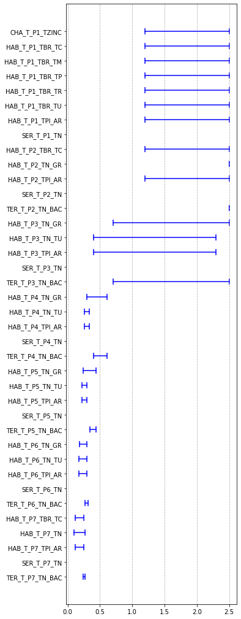

```python
y = disp_roof.DISPOSITIF_T1

fig, ax = plt.subplots(figsize=(5,18))
# plot min and max values connected
ax.scatter(disp_roof['Uph_min'], y, marker="|", s= 100, color="blue")
ax.scatter(disp_roof['Uph_max'], y, marker="|", s=100,color="blue")
ax.plot(X_coords, Y_coords, color='blue')

plt.gca().invert_yaxis()
ax.grid(True,which="both", axis="x", linestyle='--')
```

```python
disp_roof.columns[10:]
```

```
Index(['Uph_0_ah', 'Uph_0_b', 'Uph_0_c', 'Uph_0_de', 'Uph_0_fgij',
       'Uph_inc_H1_joule', 'Uph_inc_H1_autre', 'Uph_inc_H2_joule',
       'Uph_inc_H2_autre', 'Uph_inc_H3_joule', 'Uph_inc_H3_autre', 'Uph_R_ah',
       'Uph_R_b', 'Uph_R_c', 'Uph_R_de', 'Uph_R_fgij', 'Uph_E_ah', 'Uph_E_b',
       'Uph_E_c', 'Uph_E_de', 'Uph_E_fgij', 'Uph_annee_H1',
       'Uph_annee_H1_option2', 'Uph_annee_H2', 'Uph_annee_H2_option2',
       'Uph_annee_H3', 'Uph_annee_H3_option2', 'Uph_min', 'Uph_max'],
      dtype='object')
```

#### All values

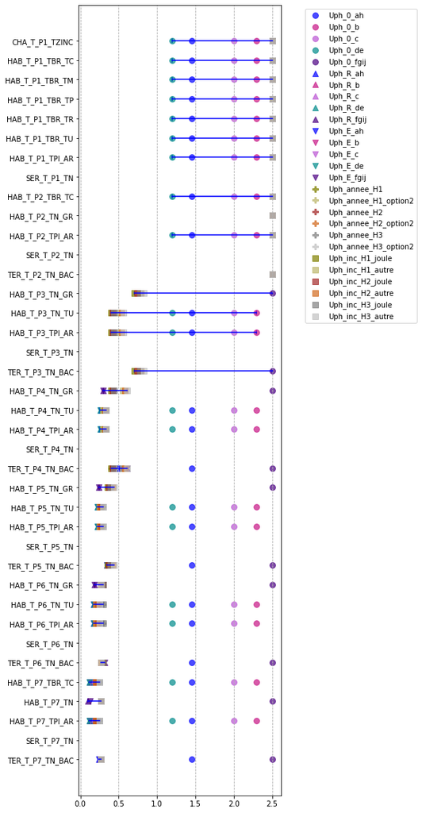

```python
y = disp_roof.DISPOSITIF_T1

fig, ax = plt.subplots(figsize=(5,20))

# plot min and max values connected
ax.scatter(disp_roof['Uph_min'], y, marker="|", color="blue")
ax.scatter(disp_roof['Uph_max'], y, marker="|", color="blue")
ax.plot(X_coords, Y_coords, color='blue')

alp = 0.7
size = 60
# Uph_0

i=0
for col in disp_roof.columns[10:15]:
    ax.scatter(disp_roof[col], y, label=col,alpha=alp,s=size, color=color_letter[i])
    i+=1

# Isolé R connu
i=0
for col in disp_roof.columns[21:26]:
    ax.scatter(disp_roof[col], y, label=col,alpha=alp,s=size, color=color_letter[i], marker="^" )
    i+=1

# Isolé e connu
i=0
for col in disp_roof.columns[26:31]:
    ax.scatter(disp_roof[col], y, label=col,alpha=alp,s=size, color=color_letter[i], marker="v" )
    i+=1

# Isolé année connue
i=0
for col in disp_roof.columns[31:37]:
    ax.scatter(disp_roof[col], y, label=col,alpha=alp,s=size, color=color_region[i], marker="P" )
    i+=1

# Isolation inconnue
i=0
for col in disp_roof.columns[15:21]:
    ax.scatter(disp_roof[col], y, label=col, alpha=alp,s=size, color=color_region[i], marker="s", )
    i+=1

plt.legend(bbox_to_anchor=(1.1, 1))
plt.gca().invert_yaxis()
ax.grid(True,which="both", axis="x", linestyle='--')
```

#### Non insulated hypothesis

```python
disp_roof_NINS = disp_roof[cond_non_is]
```

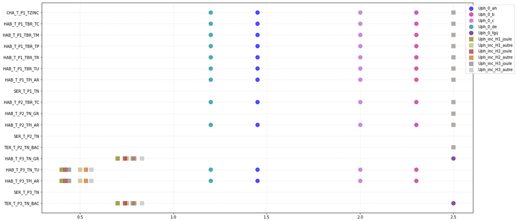

```python
y = disp_roof_NINS.DISPOSITIF_T1

fig, ax = plt.subplots(figsize=(20,10))

alp = 0.7

# Uph_0
i=0
for col in disp_roof_NINS.columns[10:15]:
    ax.scatter(disp_roof_NINS[col], y, label=col,alpha=alp,s=100, color=color_letter[i],)
    i+=1

# Isolation inconnue
i=0
for col in disp_roof_NINS.columns[15:21]:
    ax.scatter(disp_roof_NINS[col], y, label=col, alpha=alp, s=100, color=color_region[i], marker="s")
    i+=1


plt.legend(bbox_to_anchor=(1.1, 1))
plt.gca().invert_yaxis()
ax.grid(True,which="both", linestyle='--',alpha=0.3)
```

#### Insulated

```python
disp_roof[cond_is]
```

|  | DISPOSITIF_T1 | PORTEUR_T1 | EP_PORTEUR_T1 | ISOLANT_T1 | EP_ISOLANT_T1 | REVETEMENT_EXT_T1 | EP_RE_T1 | REVETEMENT_INT_T1 | EP_RI_T1 | period | ... | Uph_E_de | Uph_E_fgij | Uph_annee_H1 | Uph_annee_H1_option2 | Uph_annee_H2 | Uph_annee_H2_option2 | Uph_annee_H3 | Uph_annee_H3_option2 | Uph_min | Uph_max |
| --- | --- | --- | --- | --- | --- | --- | --- | --- | --- | --- | --- | --- | --- | --- | --- | --- | --- | --- | --- | --- | --- |
| 13 | HAB_T_P4_TN_GR | DALLE BETON | 20 | ITI_LM | 12 | GRAVIER | 5.0 | PLAQUE DE PLATRE | 1.3 | P4 | ... | NaN | 0.294118 | 0.40 | NaN | 0.42 | NaN | 0.44 | NaN | 0.294118 | 0.61000 |
| 14 | HAB_T_P4_TN_TU | STRUCTURE BOIS | 0 | ITI_LM | 12 | TUILE | 2.0 | PLAQUE DE PLATRE | 1.3 | P4 | ... | 0.260870 | NaN | 0.30 | NaN | 0.32 | NaN | 0.33 | NaN | 0.260870 | 0.33000 |
| 15 | HAB_T_P4_TPI_AR | STRUCTURE BOIS | 0 | ITI_LM | 12 | ARDOISE | 2.0 | PLAQUE DE PLATRE | 1.3 | P4 | ... | 0.260870 | NaN | 0.30 | NaN | 0.32 | NaN | 0.33 | NaN | 0.260870 | 0.33000 |
| 34 | TER_T_P4_TN_BAC | STRUCTURE METAL | 0 | ITI_LM | 5 | TOLE | 0.8 | NON | 0.0 | P4 | ... | NaN | 0.606061 | 0.40 | NaN | 0.42 | NaN | 0.44 | NaN | 0.400000 | 0.61000 |
| 16 | HAB_T_P5_TN_GR | DALLE BETON | 20 | ITI_LM | 15 | GRAVIER | 5.0 | PLAQUE DE PLATRE | 1.3 | P5 | ... | NaN | 0.240964 | 0.35 | NaN | 0.37 | NaN | 0.39 | NaN | 0.240964 | 0.44000 |
| 17 | HAB_T_P5_TN_TU | STRUCTURE BOIS | 0 | ITI_LM | 15 | TUILE | 2.0 | PLAQUE DE PLATRE | 1.3 | P5 | ... | 0.218182 | NaN | 0.25 | NaN | 0.26 | NaN | 0.30 | NaN | 0.218182 | 0.30000 |
| 18 | HAB_T_P5_TPI_AR | STRUCTURE BOIS | 0 | ITI_LM | 15 | ARDOISE | 2.0 | PLAQUE DE PLATRE | 1.3 | P5 | ... | 0.218182 | NaN | 0.25 | NaN | 0.26 | NaN | 0.30 | NaN | 0.218182 | 0.30000 |
| 35 | TER_T_P5_TN_BAC | STRUCTURE METAL | 0 | ITI_LM | 9 | TOLE | 0.8 | NON | 0.0 | P5 | ... | NaN | 0.377358 | 0.35 | NaN | 0.37 | NaN | 0.39 | NaN | 0.340176 | 0.44000 |
| 19 | HAB_T_P6_TN_GR | DALLE BETON | 20 | ITI_LM | 20 | GRAVIER | 5.0 | PLAQUE DE PLATRE | 1.3 | P6 | ... | NaN | 0.185185 | 0.30 | 0.27 | 0.30 | 0.27 | 0.30 | 0.27 | 0.185185 | 0.30000 |
| 20 | HAB_T_P6_TN_TU | STRUCTURE BOIS | 0 | ITI_LM | 20 | TUILE | 2.0 | PLAQUE DE PLATRE | 1.3 | P6 | ... | 0.171429 | NaN | 0.23 | 0.20 | 0.23 | 0.20 | 0.30 | 0.25 | 0.171429 | 0.30000 |
| 21 | HAB_T_P6_TPI_AR | STRUCTURE BOIS | 0 | ITI_LM | 20 | ARDOISE | 2.0 | PLAQUE DE PLATRE | 1.3 | P6 | ... | 0.171429 | NaN | 0.23 | 0.20 | 0.23 | 0.20 | 0.30 | 0.25 | 0.171429 | 0.30000 |
| 36 | TER_T_P6_TN_BAC | STRUCTURE METAL | 0 | ITI_LM | 11 | TOLE | 0.8 | NON | 0.0 | P6 | ... | NaN | 0.317460 | 0.30 | 0.27 | 0.30 | 0.27 | 0.30 | 0.27 | 0.270000 | 0.31746 |
| 22 | HAB_T_P7_TBR_TC | STRUCTURE BOIS | 0 | ITI_LM | 30 | TUILE | 2.0 | PLAQUE DE PLATRE | 1.3 | P7 | ... | 0.120000 | NaN | 0.20 | NaN | 0.20 | NaN | 0.25 | NaN | 0.120000 | 0.25000 |
| 23 | HAB_T_P7_TN | DALLE BETON | 20 | ITE_POL | 30 | GRAVIER | 10.0 | NON | 0.0 | P7 | ... | NaN | 0.126582 | 0.27 | NaN | 0.27 | NaN | 0.27 | NaN | 0.096154 | 0.27000 |
| 24 | HAB_T_P7_TPI_AR | STRUCTURE BOIS | 0 | ITI_LM | 30 | ARDOISE | 2.0 | PLAQUE DE PLATRE | 1.3 | P7 | ... | 0.120000 | NaN | 0.20 | NaN | 0.20 | NaN | 0.25 | NaN | 0.120000 | 0.25000 |
| 37 | TER_T_P7_TN_BAC | STRUCTURE METAL | 0 | ITI_LM | 14 | TOLE | 0.8 | NON | 0.0 | P7 | ... | NaN | 0.256410 | 0.27 | NaN | 0.27 | NaN | 0.27 | NaN | 0.238683 | 0.27000 |

16 rows × 39 columns

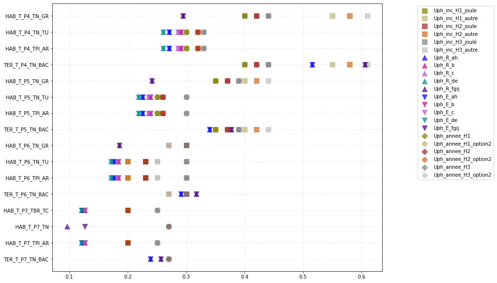

```python
disp_roof_INS =  disp_roof[cond_is]
y = disp_roof_INS.DISPOSITIF_T1

fig, ax = plt.subplots(figsize=(12,10))

alp = 0.7
size = 100

# Isolation inconnue
i=0
for col in disp_roof_INS.columns[15:21]:
    ax.scatter(disp_roof_INS[col], y, label=col, alpha=alp,s=size, color=color_region[i], marker="s", )
    i+=1

# Isolé R connu
i=0
for col in disp_roof_INS.columns[21:26]:
    ax.scatter(disp_roof_INS[col], y, label=col,alpha=alp,s=size, color=color_letter[i], marker="^" )
    i+=1

# Isolé e connu
i=0
for col in disp_roof_INS.columns[26:31]:
    ax.scatter(disp_roof_INS[col], y, label=col,alpha=alp,s=size, color=color_letter[i], marker="v" )
    i+=1

# Isolé e connu
i=0
for col in disp_roof_INS.columns[31:37]:
    ax.scatter(disp_roof_INS[col], y, label=col,alpha=alp,s=size, color=color_region[i], marker="P" )
    i+=1

plt.legend(bbox_to_anchor=(1.1, 1))
plt.gca().invert_yaxis()
ax.grid(True,which="both", linestyle='--',alpha=0.3)
```

```python
Uph = 0.3
Uph0 = 1.45

e = 0.04 * ( 1 /Uph - 1 /Uph0 ) *100
e
```

```
10.574712643678161
```

```python
disp_roof[disp_roof["DISPOSITIF_T1"]=="TER_T_P6_TN_BAC"]
```

|  | DISPOSITIF_T1 | PORTEUR_T1 | EP_PORTEUR_T1 | ISOLANT_T1 | EP_ISOLANT_T1 | REVETEMENT_EXT_T1 | EP_RE_T1 | REVETEMENT_INT_T1 | EP_RI_T1 | period | ... | Uph_E_de | Uph_E_fgij | Uph_annee_H1 | Uph_annee_H1_option2 | Uph_annee_H2 | Uph_annee_H2_option2 | Uph_annee_H3 | Uph_annee_H3_option2 | Uph_min | Uph_max |
| --- | --- | --- | --- | --- | --- | --- | --- | --- | --- | --- | --- | --- | --- | --- | --- | --- | --- | --- | --- | --- | --- |
| 36 | TER_T_P6_TN_BAC | STRUCTURE METAL | 0 | ITI_LM | 11 | TOLE | 0.8 | NON | 0.0 | P6 | ... | NaN | 0.31746 | 0.3 | 0.27 | 0.3 | 0.27 | 0.3 | 0.27 | 0.27 | 0.31746 |

1 rows × 39 columns

```python
Uph = 0.4
Uph0 = 2.5

e = 0.04 * ( 1 /Uph - 1 /Uph0 ) *100
e
```

```
8.4
```

```python
Uph = 0.61
Uph0 = 2.5

e = 0.04 * ( 1 /Uph - 1 /Uph0 ) *100
e
```

```
4.957377049180328
```

```python
disp_roof[disp_roof["DISPOSITIF_T1"]=="HAB_T_P4_TN_GR"]
```

|  | DISPOSITIF_T1 | PORTEUR_T1 | EP_PORTEUR_T1 | ISOLANT_T1 | EP_ISOLANT_T1 | REVETEMENT_EXT_T1 | EP_RE_T1 | REVETEMENT_INT_T1 | EP_RI_T1 | period | ... | Uph_E_de | Uph_E_fgij | Uph_annee_H1 | Uph_annee_H1_option2 | Uph_annee_H2 | Uph_annee_H2_option2 | Uph_annee_H3 | Uph_annee_H3_option2 | Uph_min | Uph_max |
| --- | --- | --- | --- | --- | --- | --- | --- | --- | --- | --- | --- | --- | --- | --- | --- | --- | --- | --- | --- | --- | --- |
| 13 | HAB_T_P4_TN_GR | DALLE BETON | 20 | ITI_LM | 12 | GRAVIER | 5.0 | PLAQUE DE PLATRE | 1.3 | P4 | ... | NaN | 0.294118 | 0.4 | NaN | 0.42 | NaN | 0.44 | NaN | 0.294118 | 0.61 |

1 rows × 39 columns

```python
Uph = 0.27
Uph0 = 2.5

e = 0.04 * ( 1 /Uph - 1 /Uph0 ) *100
e
```

```
13.214814814814812
```

```python
disp_roof[disp_roof["DISPOSITIF_T1"]=="HAB_T_P6_TN_GR"]
```

|  | DISPOSITIF_T1 | PORTEUR_T1 | EP_PORTEUR_T1 | ISOLANT_T1 | EP_ISOLANT_T1 | REVETEMENT_EXT_T1 | EP_RE_T1 | REVETEMENT_INT_T1 | EP_RI_T1 | period | ... | Uph_E_de | Uph_E_fgij | Uph_annee_H1 | Uph_annee_H1_option2 | Uph_annee_H2 | Uph_annee_H2_option2 | Uph_annee_H3 | Uph_annee_H3_option2 | Uph_min | Uph_max |
| --- | --- | --- | --- | --- | --- | --- | --- | --- | --- | --- | --- | --- | --- | --- | --- | --- | --- | --- | --- | --- | --- |
| 19 | HAB_T_P6_TN_GR | DALLE BETON | 20 | ITI_LM | 20 | GRAVIER | 5.0 | PLAQUE DE PLATRE | 1.3 | P6 | ... | NaN | 0.185185 | 0.3 | 0.27 | 0.3 | 0.27 | 0.3 | 0.27 | 0.185185 | 0.3 |

1 rows × 39 columns

```python
disp_roof[disp_roof["DISPOSITIF_T1"]=="TER_T_P6_TN_BAC"]
```

|  | DISPOSITIF_T1 | PORTEUR_T1 | EP_PORTEUR_T1 | ISOLANT_T1 | EP_ISOLANT_T1 | REVETEMENT_EXT_T1 | EP_RE_T1 | REVETEMENT_INT_T1 | EP_RI_T1 | period | ... | Uph_E_de | Uph_E_fgij | Uph_annee_H1 | Uph_annee_H1_option2 | Uph_annee_H2 | Uph_annee_H2_option2 | Uph_annee_H3 | Uph_annee_H3_option2 | Uph_min | Uph_max |
| --- | --- | --- | --- | --- | --- | --- | --- | --- | --- | --- | --- | --- | --- | --- | --- | --- | --- | --- | --- | --- | --- |
| 36 | TER_T_P6_TN_BAC | STRUCTURE METAL | 0 | ITI_LM | 11 | TOLE | 0.8 | NON | 0.0 | P6 | ... | NaN | 0.31746 | 0.3 | 0.27 | 0.3 | 0.27 | 0.3 | 0.27 | 0.27 | 0.31746 |

1 rows × 39 columns

## Connect with Danube

```python
df.head()
```

| NUMERO_TYPOLOGIE | USAGE | NOM_TYPOLOGIE | PERIODE | TERRITOIRE | DISPOSITIF_M1 | PORTEUR_M1 | EP_PORTEUR_M1 | ISOLANT_M1 | EP_ISOLANT_M1 | REVETEMENT_INT_M1 | ... | DISPOSITIF_T1 | PORTEUR_T1 | EP_PORTEUR_T1 | ISOLANT_T1 | EP_ISOLANT_T1 | REVETEMENT_INT_T1 | EP_RI_T1 | REVETEMENT_EXT_T1 | EP_RE_T1 | arch |
| --- | --- | --- | --- | --- | --- | --- | --- | --- | --- | --- | --- | --- | --- | --- | --- | --- | --- | --- | --- | --- | --- |
| AGR_BA_P1_TBR_TF | BATIMENT AGRICOLE | BA | P1 | FRANCE | PAV_M_P1_TBr_br | BRIQUE PLEINE | 60 | NON | 0 | ENDUIT | ... | HAB_T_P1_TBR_TU | STRUCTURE BOIS | 0 | NON | 0 | NON | 0.0 | TUILE | 2.0 | P1-BA-BATIMENT AGRICOLE-FRANCE |
| AGR_BA_P1_TBO_ARD | BATIMENT AGRICOLE | BA | P1 | FRANCE_BOIS_ARDOISE | PAV_M_P1_TBo-bo | BOIS | 50 | IR | 0 | NON | ... | HAB_T_P1_TPI_AR | STRUCTURE BOIS | 0 | NON | 0 | NON | 0.0 | ARDOISE | 2.0 | P1-BA-BATIMENT AGRICOLE-FRANCE_BOIS_ARDOISE |
| AGR_BA_P1_TBO_TUI | BATIMENT AGRICOLE | BA | P1 | FRANCE_BOIS_TUILE | PAV_M_P1_TBo-bo | BOIS | 50 | IR | 0 | NON | ... | HAB_T_P1_TBR_TM | STRUCTURE BOIS | 0 | NON | 0 | NON | 0.0 | TUILE MECANIQUE | 2.0 | P1-BA-BATIMENT AGRICOLE-FRANCE_BOIS_TUILE |
| AGR_BA_P1_TBR_TUI | BATIMENT AGRICOLE | BA | P1 | FRANCE_BRIQUE_TUILE | PAV_M_P1_TBr_br | BRIQUE PLEINE | 60 | NON | 0 | ENDUIT | ... | HAB_T_P1_TBR_TU | STRUCTURE BOIS | 0 | NON | 0 | NON | 0.0 | TUILE | 2.0 | P1-BA-BATIMENT AGRICOLE-FRANCE_BRIQUE_TUILE |
| AGR_BA_P1_TCAL_ARD | BATIMENT AGRICOLE | BA | P1 | FRANCE_PIERRE_CALCAIRE_ARDOISE | PAV_M_P1_TPi_Cal | CALCAIRE | 80 | NON | 0 | NON | ... | HAB_T_P1_TPI_AR | STRUCTURE BOIS | 0 | NON | 0 | NON | 0.0 | ARDOISE | 2.0 | P1-BA-BATIMENT AGRICOLE-FRANCE_PIERRE_CALCAIRE... |

5 rows × 69 columns

```python
disp_roof.head()
```

|  | DISPOSITIF_T1 | PORTEUR_T1 | EP_PORTEUR_T1 | ISOLANT_T1 | EP_ISOLANT_T1 | REVETEMENT_EXT_T1 | EP_RE_T1 | REVETEMENT_INT_T1 | EP_RI_T1 | period | ... | Uph_E_de | Uph_E_fgij | Uph_annee_H1 | Uph_annee_H1_option2 | Uph_annee_H2 | Uph_annee_H2_option2 | Uph_annee_H3 | Uph_annee_H3_option2 | Uph_min | Uph_max |
| --- | --- | --- | --- | --- | --- | --- | --- | --- | --- | --- | --- | --- | --- | --- | --- | --- | --- | --- | --- | --- | --- |
| 0 | CHA_T_P1_TZINC | STRUCTURE BOIS | 0 | NON | 0 | COUVERTURE ZINC | 1.0 | NON | 0.0 | P1 | ... | NaN | NaN | NaN | NaN | NaN | NaN | NaN | NaN | 1.2 | 2.5 |
| 1 | HAB_T_P1_TBR_TC | STRUCTURE BOIS | 0 | NON | 0 | TUILE CANAL | 2.0 | NON | 0.0 | P1 | ... | NaN | NaN | NaN | NaN | NaN | NaN | NaN | NaN | 1.2 | 2.5 |
| 2 | HAB_T_P1_TBR_TM | STRUCTURE BOIS | 0 | NON | 0 | TUILE MECANIQUE | 2.0 | NON | 0.0 | P1 | ... | NaN | NaN | NaN | NaN | NaN | NaN | NaN | NaN | 1.2 | 2.5 |
| 3 | HAB_T_P1_TBR_TP | STRUCTURE BOIS | 0 | NON | 0 | TUILE PLATE | 2.0 | NON | 0.0 | P1 | ... | NaN | NaN | NaN | NaN | NaN | NaN | NaN | NaN | 1.2 | 2.5 |
| 4 | HAB_T_P1_TBR_TR | STRUCTURE BOIS | 0 | NON | 0 | TUILE ROMAINE | 2.0 | NON | 0.0 | P1 | ... | NaN | NaN | NaN | NaN | NaN | NaN | NaN | NaN | 1.2 | 2.5 |

5 rows × 39 columns

```python
disp_roof.to_excel("U-values_disp_roof.xlsx")
```